# Cobb01713494_DataScience

## Outline

- Task 1: Regression
  - 1.1 Linear regression
  - 1.2 Ridge regression
  - 1.3 Relaxation of Lasso regression
- Task 2: Classification
  - 2.1 kNN classifier
  - 2.2 Random forest
  - 2.3 Support vector machine (SVM)
- Task 3: Mastery component
  - 3.1 Logistic regression and bagging
  - 3.2 Kernelised SVM classifier

# Task 1: Regression ^

1. go through and write up properly
2. docstring for every function
3. adhere to my comments
4. little introduction to ech section
5. do for standardised, but put in a table with non standardised and see how it looks for ridge and lasso. also plot mse.

nb add docstrings to all my functions!!! but d docstrings wiht just what the functio ndoes.

```python
import numpy as np
import pandas as pd
import matplotlib.pyplot as plt
import seaborn as sns
from tabulate import tabulate
from collections import defaultdict
```

```python
chemistry = pd.read_csv('chemistry_samples.csv')
chemistry.head()  # Observe the first 5 rows to see how the data is presented.
```

|  | CIC0 | SM1_Dz(Z) | GATS1i | NdsCH | NdssC | MLOGP | FV1 | VFV | FV2 | FV3 | LC50 |
| --- | --- | --- | --- | --- | --- | --- | --- | --- | --- | --- | --- |
| 0 | 3.661280 | 0.658363 | 1.602232 | 1.994272 | 0.836488 | 3.153623 | 15.893033 | -27.724370 | 0.059355 | 0.756698 | 5.506249 |
| 1 | 3.936362 | 1.154287 | 1.146997 | 0.904295 | 2.948308 | 5.141095 | 13.590177 | -31.821521 | -13.408855 | 1.161298 | 6.636791 |
| 2 | 0.964144 | 0.415485 | 1.481028 | 2.136585 | 0.043679 | -1.156783 | 15.989419 | -3.699312 | 2.561525 | 0.500115 | 1.563388 |
| 3 | 2.074617 | 1.417296 | 0.486216 | 0.000908 | -0.066980 | 2.610960 | 7.962046 | -16.374439 | 2.448975 | 1.481888 | 6.248432 |
| 4 | 1.448569 | 0.836892 | 1.951012 | 0.028318 | -0.039121 | 1.851095 | 22.285266 | -9.526361 | 2.870400 | 0.649234 | 3.676796 |

```python
# Initialise the data into arrays we can easily work with.
train_data_1 = np.genfromtxt('chemistry_samples.csv', delimiter=',')[1:]  # Set up data as an array we can work with.
X_without_LC50 = train_data_1[:, :-1]  # Remove the LC50 column from X.
LC50 = np.squeeze(train_data_1[:, -1:])  # Store the LC50 column of X and squeeze to make a column vector.
```

```python
print(LC50)  # Check the shape of LC50.
```

```
[5.50624904 6.63679062 1.56338835 ... 2.69148529 2.0964496  3.54278485]
```

```python
X_without_LC50  # Check we have set up the matrix correctly with LC50 column removed.
```

```
array([[  3.66128031,   0.6583629 ,   1.60223211, ..., -27.72437047,
          0.05935524,   0.75669839],
       [  3.93636196,   1.15428669,   1.14699685, ..., -31.82152098,
        -13.4088554 ,   1.16129782],
       [  0.96414423,   0.41548471,   1.48102815, ...,  -3.69931184,
          2.56152478,   0.50011507],
       ...,
       [  2.51236737,   0.32482337,   1.92092273, ..., -18.68991454,
          3.20054418,   0.43171143],
       [  2.59789504,   0.33506789,   1.60876265, ..., -20.05056624,
          4.58663228,   0.22232813],
       [  3.05333312,   0.41659284,   1.64666328, ..., -22.75547707,
         -2.82234037,   0.54801066]])
```

We note that the data has been scanned for duplicates and non-float entries but non were found; the data is clean.

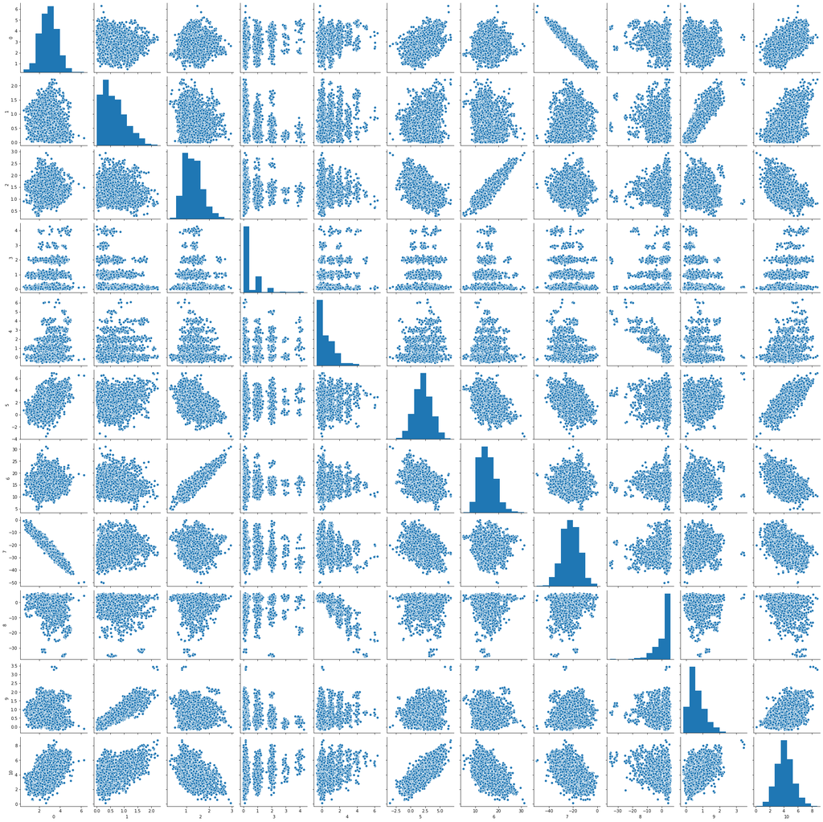

```python
sns.pairplot(pd.DataFrame(train_data_1[:, :]))  # Oberserve the general relationship between each variable pair.
```

We consider a regression problem of the form $$ y = \boldsymbol x^T\boldsymbol\beta + \epsilon\,,\quad \epsilon \sim \mathcal N(0, \sigma^2) $$ where $\boldsymbol x\in\mathbb{R}^D$ are inputs and $y\in\mathbb{R}$ are noisy observations. The parameter vector $\boldsymbol\beta\in\mathbb{R}^D$ parametrizes the function and we attempt to find its optimal value for the data and subsequent unseen test data.

We assume we have a training set $(\boldsymbol x_n, y_n)$, $n=1,\ldots, N$ and summarize the sets of training inputs in $\mathcal X = \{\boldsymbol x_1, \ldots, \boldsymbol x_N\}$ and corresponding training targets $\mathcal Y = \{y_1, \ldots, y_N\}$, respectively. Of course, $\boldsymbol x_i$ refers to the $i^{th}$ row of a larger matrix $\boldsymbol X_{n \times d}$, as discussed in lectures.

We are interested in finding parameters $\boldsymbol\beta$ that map the inputs well to the ouputs. However, the optimal $\boldsymbol\beta$ can be found in multiple different ways, each with their own advantages and optimal suggestion.

For general regression problems of the above form we need to add a column of ones as the first column of $\boldsymbol X$. This is to add a neccessary intercept term to our regression. For simplicity, we will add this column of ones inside each function, maintaining $\boldsymbol X$ to be the matrix initialised above.

## 1.1 ^

### 1.1.2

### Linear Regression

From the lectures, we know that the simplest suggestion for $\boldsymbol\beta$ can be found by optimizing following equation: $$ \underset{\boldsymbol\beta}{\text{min}} \| \mathcal Y - \mathcal X \boldsymbol\beta \|^2 = \underset{\boldsymbol\beta}{\text{min}} \ \text{L}_{\text{LS}} (\boldsymbol\beta) $$ where $\text{L}_{\text{LS}}$ is the (ordinary) least squares loss function. The solution is $$ \boldsymbol\beta^{*} = (\boldsymbol X^T\boldsymbol X)^{-1}\boldsymbol X^T\boldsymbol y \ \in\mathbb{R}^D\,, $$ where $$ \boldsymbol X = [\boldsymbol x_1, \ldots, \boldsymbol x_N]^T\in\mathbb{R}^{N\times D}\,,\quad \boldsymbol y = [y_1, \ldots, y_N]^T \in\mathbb{R}^N\,. $$

The same estimate of $\boldsymbol\beta$ we can be obtained by maximum liklihood estimation which gives statistical interpretation of linear regression. In maximum likelihood estimation, we can find the parameters $\boldsymbol\beta^{\mathrm{ML}}$ that maximize the likelihood $$ p(\mathcal Y | \mathcal X, \boldsymbol\beta) = \prod_{n=1}^N p(y_n | \boldsymbol x_n, \boldsymbol\beta)\,. $$ From derivations discussed in lectures, we know that the maximum likelihood estimator is given by $$ \boldsymbol\beta^{\text{ML}} = (\boldsymbol X^T\boldsymbol X)^{-1}\boldsymbol X^T\boldsymbol y \, . $$

Throughout this notebook we run functions and compute values in a pythonic way, calling functions within functions. The maximum likelihood estimate for the given training set can be found as follows:

```python
def max_lik_estimate(X, y):
    '''
    Find the optimal beta parameters using least squares optimisation.
    '''
    X_aug = np.hstack([np.ones((X.shape[0],1)), X])  # Augment X to add a column of ones.
    N, D = X_aug.shape
    betas_ml = np.linalg.solve(X_aug.T @ X_aug, X_aug.T @ y)
    return betas_ml
```

```python
betas_ml = max_lik_estimate(X_without_LC50, LC50)  # Store our least squares beta parameters for the training data set.
for i in range(len(betas_ml)):
    print(f'β{i} = {betas_ml[i]:.3}')  # Report the inferred values of the model parameters.
```

```
β0 = 2.62
β1 = 0.0447
β2 = 1.26
β3 = -0.038
β4 = 0.363
β5 = 0.00467
β6 = 0.391
β7 = -0.0746
β8 = -0.0357
β9 = -0.0153
β10 = -0.0018
```

```python
def predict_with_estimate(X_test, betas):
    '''
    Predict each entry in the test output vector y using a vector of beta parameters.
    '''
    X_test_aug = np.hstack([np.ones((X_test.shape[0],1)), X_test])  # Augment X to add a column of ones. We will not comment this for the remainder of the notebook.
    prediction = X_test_aug @ betas
    return prediction
```

```python
def find_R_squared_score(X, y, betas):
    '''
    Find the R^2 score using a vector of beta parameters
    '''
    e = y - predict_with_estimate(X, betas)  # The error for each entry.
    SSres = e.T @ e

    y_bar = sum(y)/len(y)
    SStot = np.sum([(y_i - y_bar)**2 for y_i in y])

    R_squared_score = 1 - SSres/SStot
    return R_squared_score
```

The in-sample $R^2$ score using least squares optimsation for the data set is

```python
is_R_squared = find_R_squared_score(X_without_LC50, LC50, betas_ml)
is_R_squared
```

```
0.8718259975718016
```

### 1.1.2

```python
chemistry_test = pd.read_csv('chemistry_test.csv')  # Read in the unseen test data set to evaluate our predictions.
chemistry_test.head()
```

|  | CIC0 | SM1_Dz(Z) | GATS1i | NdsCH | NdssC | MLOGP | FV1 | VFV | FV2 | FV3 | LC50 |
| --- | --- | --- | --- | --- | --- | --- | --- | --- | --- | --- | --- |
| 0 | 1.617579 | 0.376167 | 1.224281 | 0.849464 | 1.101738 | -0.448372 | 14.913614 | -9.091450 | -1.953849 | 0.328298 | 1.791786 |
| 1 | 4.278766 | 0.514788 | 1.259734 | 0.210436 | 0.819626 | 4.446118 | 12.904817 | -37.986185 | -2.804426 | 0.452758 | 6.125609 |
| 2 | 3.578652 | 0.221018 | 1.552583 | 1.007153 | -0.013073 | 1.960720 | 17.393050 | -27.188863 | 3.565159 | 0.341665 | 3.953270 |
| 3 | 3.021762 | 1.602774 | 1.044233 | 0.054776 | 2.060890 | 4.510903 | 12.777434 | -22.710306 | -7.966119 | 1.729511 | 6.995314 |
| 4 | 2.487163 | 0.799948 | 1.005727 | 0.094923 | 0.146542 | 2.298082 | 13.336721 | -16.839870 | 2.607198 | 0.904353 | 5.253633 |

```python
# Initialise the data into the same array format as before.
test_data_1 = np.genfromtxt('chemistry_test.csv', delimiter=',')[1:]
X_test_without_LC50 = test_data_1[:, :-1]
LC50_test = np.squeeze(test_data_1[:, -1:])
```

```python
oos_R_squared = find_R_squared_score(X_test_without_LC50, LC50_test, betas_ml)

adjusted_is_R_squared = 1 - ((1 - is_R_squared)*(X_without_LC50.shape[0] - 1)) / (X_without_LC50.shape[0] - X_without_LC50.shape[1] - 1)
adjusted_oos_R_squared = 1 - ((1 - oos_R_squared)*(X_test_without_LC50.shape[0] - 1)) / (X_test_without_LC50.shape[0] - X_test_without_LC50.shape[1] - 1)


R_scores = [{is_R_squared, oos_R_squared, adjusted_is_R_squared, adjusted_oos_R_squared}]
head = ['\033[1m' + "In-sample R^2", "Out-of-sample R^2", 'In-sample Adjusted R^2', 'Out-of-sample Adjusted R^2' + '\033[0m']  # Creat the table header.
print(tabulate(R_scores, headers=head, tablefmt="grid"))  # Display the table.
```

```
+-----------------+---------------------+--------------------------+------------------------------+
|   In-sample R^2 |   Out-of-sample R^2 |   In-sample Adjusted R^2 |   Out-of-sample Adjusted R^2 |
+=================+=====================+==========================+==============================+
|        0.871826 |            0.864293 |                 0.871513 |                     0.862959 |
+-----------------+---------------------+--------------------------+------------------------------+
```

The $R^2$ score can be interpreted as the fraction by which the variance of the errors is less than the variance of the dependant variables. Equivalently, the $R^2$ score is equal to the square of the correlation between the dependant variables and the model's predictions for them; the $R^2$ score is determined by the pairwise correlations amongst all of the dependant and independant variables in the model. The adjusted $R^2$ is a modified version of $R^2$ that has been adjusted for the number of predictors in the model. The adjusted $R^2$ score increases when a new predictor improves the model (more than would be expected by chance) and decreases if a predictor does not improve the model.

From the table above, we can see that approximately 87\% of the training data can be explained by and fits our regression model. Furthermore, we see that approximately 86\% of our test data fits the least squares linear regression model trained on the training data set, suggesting our regression model is a good fit. As expected, the out-of-sample $R^2$ score is lower than the in-sample score, but only slightly. This indicates that the model is not over fitting to the training data and can generalise to explain new data sets of the same variety.

The normal $R^2$ score, however, has some drawback. Namely, every time you add a new predictor to the model the $R^2$ score increases meaning a model with many predictors may appear to be a better fit simply because it has more terms. In addition, a model with too many predictors starts to model the random noise in the data and essentially overfits to the training data set. The adjusted $R^2$ score alleviates these pitfalls by taking into account the number of predictors. Our similarly high adjusted $R^2$ scores, for both in-sample and out-of-sample data, display the goodness of fit of our regression model.

## 1.2 ^

### 1.2.1

Whilst not necessary in least squares linear regression, in ridge and Lasso regression we need to work with standardised data. This is to ensure that all variables contribute equally to the regression, regardless of their respective size. As such, we standardise our training and testing data sets:

```python
def standardise(X):
    '''
    Standardise the columns of a matrix.
    '''
    mu = np.mean(X, 0)
    sigma = np.std(X, 0)
    X_std = (X - mu) / sigma
    return X_std
```

```python
def get_mus_and_stdvs(X):
    '''
    Get the mean and standard deviation of each column.
    '''
    mu = np.mean(X, 0)
    sigma = np.std(X, 0)
    mus_and_stdvs = []
    for i in range(X.shape[1]):
        mus_and_stdvs.append([mu[i], sigma[i]])
    return mus_and_stdvs
```

```python
# Standardise the training data set.
standardised_X_without_LC50 =  standardise(X_without_LC50)
standardised_LC50 = standardise(LC50)
```

```python
# Standardise the test data set using the mean and standard deviation of each respective column in the training data set.
standardised_X_test_without_LC50 = X_test_without_LC50
mus_and_stdvs = get_mus_and_stdvs(X_without_LC50)

for j in range(X_test_without_LC50.shape[1]):
    for i in range(X_test_without_LC50.shape[0]):
        standardised_X_test_without_LC50[i, j] = (standardised_X_test_without_LC50[i, j] - mus_and_stdvs[j][0] ) / mus_and_stdvs[j][1]

standardised_LC50_test = ( LC50_test - np.mean(LC50, 0) ) / np.std(LC50, 0)
```

```python
get_mus_and_stdvs(standardised_X_without_LC50)  # Check the standardisation has worked.
```

```
[[5.156615965062826e-15, 1.0000000000000002],
 [-2.951340623282306e-15, 0.9999999999999984],
 [7.634207868964675e-15, 0.999999999999999],
 [-9.829430169613676e-16, 1.0000000000000002],
 [3.895097709600738e-16, 1.0000000000000016],
 [-3.039218651064604e-15, 0.9999999999999984],
 [3.0727062830406486e-15, 1.0000000000000009],
 [7.027173648242465e-15, 1.0000000000000018],
 [-1.826966373531789e-16, 0.9999999999999996],
 [1.907822801061045e-15, 1.0000000000000002]]
```

Ridge regression introduces a small, positive penalty term $\lambda$ that penalises large values of $\| \boldsymbol\beta \|$ leading to smaller $\beta_i$ coefficients. We attempt to minimise the ridge loss function:

$$ \underset{\boldsymbol\beta}{\text{min}} \ \text{L}_{\text{ridge}} (\boldsymbol\beta) = \underset{\boldsymbol\beta}{\text{min}} \| \mathcal Y - \mathcal X \boldsymbol\beta \|^2 + \lambda \| \boldsymbol\beta \|^2 $$

From lectures, we know that this can be solved explicitly by taking the derivative and using matrix algerbra. The solution is

$$ \boldsymbol\beta^{*}_{\text{ridge}} = (\boldsymbol X^T\boldsymbol X + \lambda I)^{-1}\boldsymbol X^T\boldsymbol y \, . $$

```python
# Shuffle the rows and columns of X, incase there is some sort of correlation that will affect our 5-fold cross-validation.
p = np.random.RandomState(seed=47).permutation(len(LC50))  # Set a seed so that our analysis is repeatable.
standardised_X_without_LC50 = standardised_X_without_LC50[p]
standardised_LC50 = standardised_LC50[p]
```

Let's define function similar to the one for least squares, but taking one additional argument, our penalty term 𝜆 .

We apply the same augmentation INSIDE THE FUNCTION as above with least squares, so the offset is accurately captured.

```python
def ridge_estimate(X, y, penalty):
    '''
    Find the optimal beta parameters using ridge regression.
    '''
    N, D = X.shape
    X_aug = np.hstack([np.ones((N,1)), X])
    N_aug, D_aug = X_aug.shape
    I = np.identity(D_aug)
    I[0, 0] = 0  # Intercept term removed to improve the shrinkage properties of ridge regression so that it is not dominated by large values of the intercept of the linear model.

    beta_ridge = np.linalg.inv(X_aug.T @ X_aug + penalty * I) @ X_aug.T @ y

    return beta_ridge
```

```python
def folds_func(y, k):
    '''
    Find the indices for a vector split into k folds.
    '''
    return np.split(np.arange(len(y) - len(y)%k), k)  # We make the size of each fold equal to maintain simplicity. In the training data this will only miss out a single data point.
```

```python
def k_fold_average_MSE_ridge_estimate(X, y, k, penalty):
    '''
    Find the average ridge mean-squared error for a particular penalty and k-fold cross-validation.
    '''
    folds = folds_func(y, k)
    MSEs = []

    for i in range(len(folds)):
        test_indices = folds[i]
        train_indices = list(set(range(len(y))) - set(test_indices))

        X_train = X[train_indices][:]
        y_train = y[train_indices]
        X_test = X[test_indices][:]
        y_test = y[test_indices]

        betas = ridge_estimate(X_train, y_train, penalty)
        e = y_test - predict_with_estimate(X_test, betas)
        SSres = e.T @ e
        MSEs.append(SSres/len(e))  # Append this fold's MSE to the list.

    average_MSE = sum(MSEs)/k  # Calculate the average across folds.
    return average_MSE
```

```
The optimal penalty to 3 s.f. is 2.18 , with a mean-squared error of 0.129
```

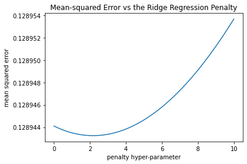

```python
MSEs = [k_fold_average_MSE_ridge_estimate(standardised_X_without_LC50, standardised_LC50, 5, penalty/100) for penalty in range(1000)]

plt.ticklabel_format(useOffset=False)
plt.plot([i/100 for i in range(1000)], MSEs)
plt.title('Mean-squared Error vs the Ridge Regression Penalty')
plt.xlabel('penalty hyper-parameter')
plt.ylabel('mean squared error')

min_MSE = min(MSEs)  # Find the minimum MSE.
min_lambda = [i/100 for i in range(1000)][MSEs.index(min_MSE)]  # Find the penalty corresponding to the minimum MSE.
print('The optimal penalty to 3 s.f. is', min_lambda, ', with a mean-squared error of', round(min_MSE, 3))
```

Having seen the general shape of our mean-squared error against penalty hyper-parameter plot, we can find the optimal penalty to 5 significant figures.

```
The optimal penalty, to 5 s.f. is 2.1752 , with a mean-squared error of 0.12894
```

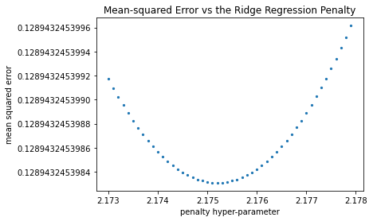

```python
MSEs = [k_fold_average_MSE_ridge_estimate(standardised_X_without_LC50, standardised_LC50, 5, 2.173 + penalty/1e4) for penalty in range(50)]

plt.ticklabel_format(useOffset=False)
plt.scatter([2.173 + i/1e4 for i in range(50)], MSEs, s=5)
plt.title('Mean-squared Error vs the Ridge Regression Penalty')
plt.xlabel('penalty hyper-parameter')
plt.ylabel('mean squared error')

min_MSE = min(MSEs)  # Find the minimum MSE.
min_lambda = [2.173 + i/1e4 for i in range(50)][MSEs.index(min_MSE)]  # Find the penalty corresponding to the minimum MSE.
print('The optimal penalty, to 5 s.f. is', round(min_lambda, 5), ', with a mean-squared error of', round(min_MSE, 5))
```

It can be easily shown that

$$ \text{MSE(}\hat{\theta}) = E[(\hat{\theta} - \theta)^2] = \text{Var(}\hat{\theta}) + \text{bias(}\hat{\theta})^2. $$

Of course, this can be extended to the multivariate case such that

$$ \text{MSE(}\hat{\underline{\theta}}) = E[(\hat{\underline{\theta}} - \underline{\theta})^2] = \text{Trace(Cov(}\underline{\hat{\theta}})) + \text{bias(}\underline{\hat{\theta}})^T\text{bias(}\underline{\hat{\theta}}). $$

In essence, this tells us that Model Error = Reducible Error + Irreducible Error.

According to this derivation of the mean-squared error, we can graphically depict why introducing bias into our parameter estimation, but simultaneously reducing the model's variance, can lead to a lower mean-squared error than the un-biased least squares estimation:

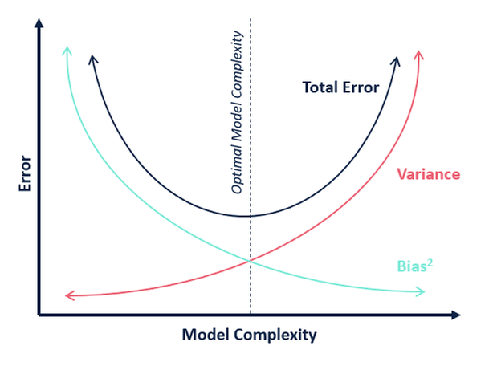

We note that graph plots Bias$^2$ as-opposed to Bias, hence the optimal value for the mean-squared error is at their crossing point.

Despite the fact that we do not know the true value of our $\beta_i$ estimators, we can make a naive approximation of them using our least squares estimation since it is un-biased. As such, we can naively mimic the above plot using our training data. We note that the following plot is merely to portray the general trend of bias, variance and mean-squared error as a function of the penalty parameter, since we do not have the true values for either $\boldsymbol{\beta}$ or $\sigma^2$.

Since ridge regression is equivalent to linear regression for $\lambda = 0$, and linear regression is un-biased, we have that $\lambda = 0 \implies \text{MSE(}\hat{\theta}) = \text{Var(}\hat{\theta}).$ As such, we can scale the sample variance calculated below such that, at $\lambda = 0$, the sample variance is equal to the cross-fold mean-squared error calculated above. Whilst this in no-way constitues $\textit{correct}$ mathematical manipulation, it does allow us to nicely observe the general trend of bias, variance and mean-squared error as a function of the penalty parameter.

```python
def naive_ridge_bias(X, y, penalty):
    '''
    Find the naive approximation for the bias, using the least squares estimation for the true beta.
    '''
    betas = ridge_estimate(X, y, penalty)
    bias = betas_ml - betas
    return bias
```

```python
def ridge_covariance(X, y, penalty):
    '''
    Find the sample covariance matrix.
    '''
    N, D = X.shape
    X_aug = np.hstack([np.ones((N,1)), X])
    N_aug, D_aug = X_aug.shape
    I = np.identity(D_aug)
    I[0][0] = 0

    mean_of_ys = np.mean(predict_with_estimate(X, ridge_estimate(X, y, penalty)))
    difference =  predict_with_estimate(X, ridge_estimate(X, y, penalty)) - mean_of_ys

    sample_error_variance = (difference.T @ difference) / (N_aug - D_aug)
    covariance = sample_error_variance * (np.linalg.inv(X_aug.T @ X_aug + penalty * I) @ X_aug.T @ X_aug) @ (np.linalg.inv(X_aug.T @ X_aug + penalty * I)).T
    return covariance
```

We compute the following values using the un-standardised data, since this has the clearest portrayal of each respective trend. As such, we note that the un-standardised mean-squared error at $\lambda = 0$ is:

```python
unstandardised_MSE = k_fold_average_MSE_ridge_estimate(X_without_LC50, LC50, 5, 0.0)
unstandardised_MSE
```

```
0.18792822110561846
```

```python
LSE_var = np.trace(ridge_covariance(X_without_LC50, LC50, 0.0))
constant = unstandardised_MSE/LSE_var  # Constant term to scale the variance.
```

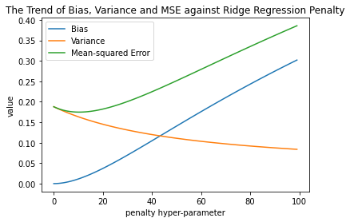

```
The minimum mean-squared error according to this method of calculation is 0.175
```

```python
biases = []
covs = []
MSEs = []

for i in range(100):
    penalty = i
    bias = naive_ridge_bias(X_without_LC50, LC50, penalty)
    covariance = ridge_covariance(X_without_LC50, LC50, penalty)
    biases.append((bias.T @ bias))
    covs.append(np.trace(covariance) * constant)
    MSEs.append(np.trace(covariance) * constant + (bias.T @ bias))

plt.ticklabel_format(useOffset=False)
plt.plot([i for i in range(100)], biases)
plt.plot([i for i in range(100)], covs)
plt.plot([i for i in range(100)], MSEs)
plt.title('The Trend of Bias, Variance and MSE against Ridge Regression Penalty')
plt.xlabel('penalty hyper-parameter')
plt.ylabel('value')
plt.legend(['Bias', 'Variance', 'Mean-squared Error'])
plt.show()

print('The minimum mean-squared error according to this method of calculation is', round(min(MSEs), 3))
```

We can therefore see some very distinct trends as the penalty hyper-parameter is increased. Firstly, as previously discussed, the mean-squared error intially decreases, converging to its minimum point, before increasing at a rate dominated by the bias$^2$. This re-emphasis how the introduction of bias to an estimator can lead to a better model fit due to the corresponding reduction in variance. Additionally, we can see that the bias increases and the variance decreases as the penalty hyper-parameter is increased.

### 1.2.2

```python
betas_ridge = ridge_estimate(standardised_X_without_LC50, standardised_LC50, 4.4417)

print(f'The in-sample ridge regression R^2 score is {find_R_squared_score(standardised_X_without_LC50, standardised_LC50, betas_ridge)}')
print(f'The out-of-sample ridge regression R^2 score is {find_R_squared_score(standardised_X_test_without_LC50, standardised_LC50_test, betas_ridge)}')
```

```
The in-sample ridge regression R^2 score is 0.8718237567523026
The out-of-sample ridge regression R^2 score is 0.8643008944186219
```

Whilst the out-of-sample $R^2$ score is again less than the in-sample $R^2$ score, we see that they are both very simliar and close to 1, suggesting the ridge regression optimal parameter estimate is also a good fit for the data. Importantly, we see that the ridge regression out-of-sample $R^2$ score of 0.86430 is slightly greater than the linear regression out-of-sample $R^2$ score 0.86429. As such, this suggests that ridge regression is marginally better than linear regression at modelling an unseen test data set.

An additional difference betweem linear and ridge regression is their respective optimal $\beta_i$ values:

```python
for i in range(len(betas_ml)):
    print(f'Linear Regression β{i} = {betas_ml[i]:.3}, Ridge Regression β{i} = {betas_ridge[i]:.3}')
```

```
Linear Regression β0 = 2.62, Ridge Regression β0 = 5.86e-15
Linear Regression β1 = 0.0447, Ridge Regression β1 = 0.0311
Linear Regression β2 = 1.26, Ridge Regression β2 = 0.443
Linear Regression β3 = -0.038, Ridge Regression β3 = -0.0141
Linear Regression β4 = 0.363, Ridge Regression β4 = 0.209
Linear Regression β5 = 0.00467, Ridge Regression β5 = 0.00425
Linear Regression β6 = 0.391, Ridge Regression β6 = 0.468
Linear Regression β7 = -0.0746, Ridge Regression β7 = -0.218
Linear Regression β8 = -0.0357, Ridge Regression β8 = -0.208
Linear Regression β9 = -0.0153, Ridge Regression β9 = -0.0659
Linear Regression β10 = -0.0018, Ridge Regression β10 = 0.00151
```

## 1.3 ^

### 1.3.1

We now implement a relaxation of Lasso regression, where we attempt to optimise the cost function given by:

$$ L_{Lasso}(\beta) = \| \textbf{y} - X \boldsymbol{\beta} \|^2 + \lambda \sum_{i}^{p} L_c(\beta_i) $$

where $L_c(\beta)$ is the differential Huber function such that

$$ L_c(\beta_i) = \begin{cases} \frac{1}{2} \beta^2 & \text{for } |\beta| \leq c, \\ c(|\beta| - \frac{1}{2}c) & \text{otherwise.} \end{cases} $$

```python
def huber(beta, c=1e-6):
    '''
    Find the huber function applied to each entry of a given vector.
    '''
    betas = np.zeros(shape=(len(beta),))
    for i in range(beta.shape[0]):
        if abs(beta[i]) <= c:
            betas[i] = 1/2 * beta[i]**2
        else:
            betas[i] = c * (abs(beta[i]) - 1/2 * c)
    return betas

def grad_huber(beta, c=1e-6):
    '''
    Find the gradient of the huber function applied to each entry of a given vector.
    '''
    betas = np.zeros(shape=(len(beta),))
    for i in range(beta.shape[0]):
        if abs(beta[i]) <= c:
            betas[i] = beta[i]
        else:
            betas[i] = np.sign(beta[i]) * c
    return betas
```

These functions can be visualised as follows:

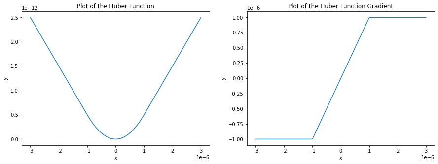

```python
x_coordinates = np.linspace(-0.000003, 0.000003, 201)

plt.figure(figsize=(15, 5))
plt.subplot(1, 2, 1)  # Index 1
plt.plot(x_coordinates, huber(x_coordinates))
plt.xlabel('x')
plt.ylabel('y')
plt.title('Plot of the Huber Function')

plt.subplot(1, 2, 2)  # Index 2
plt.plot(x_coordinates, grad_huber(x_coordinates))
plt.xlabel('x')
plt.ylabel('y')
plt.title('Plot of the Huber Function Gradient')
plt.show()
```

```python
def minimize_ls_huber(X, y, penalty, n_iters=10000, step_size=1e-2):
    '''
    Find the betas that minimise the Lasso regression cost function via iterative gradient descent.
    '''
    n, p = X.shape
    X_aug = np.hstack([np.ones((n,1)), X])
    p+= 1  # To account for the change in X's dimensions.
    betas = np.zeros(p)  # Initialise the betas.

    # Implement gradient descent for n_iters iterations. The gradient is found by differentiating the Lasso cost function.
    for i in range(n_iters):
        grad = -2/n * X_aug.T @ (y - X_aug @ betas) + penalty * np.concatenate([np.zeros([1]), grad_huber(betas[1:])])
        betas = betas - step_size * grad  # Gradient descent update.

    return betas
```

```python
minimize_ls_huber(standardised_X_without_LC50, standardised_LC50, 1, n_iters=10000, step_size=1e-3)
```

```
array([ 5.43195220e-15,  6.34119332e-02,  4.16838903e-01, -3.61664197e-02,
        2.08050215e-01,  1.22980443e-02,  4.67928325e-01, -1.96597660e-01,
       -1.75348813e-01, -5.92738542e-02,  2.74809330e-02])
```

```python
def k_fold_average_MSE_lasso_estimate(X, y, k, penalty):
    '''
    Find the average Lasso mean-squared error for a particular penalty and k-fold cross-validation.
    '''
    folds = folds_func(y, k)
    MSEs = []

    for i in range(len(folds)):
        test_indices = folds[i]
        train_indices = list(set(range(len(y))) - set(test_indices))

        X_train = X[train_indices][:]
        y_train = y[train_indices]
        X_test = X[test_indices][:]
        y_test = y[test_indices]

        betas = minimize_ls_huber(X_train, y_train, penalty)
        e = y_test - predict_with_estimate(X_test, betas)
        SSres = e.T @ e
        MSEs.append(SSres/len(e))

    average_MSE = sum(MSEs)/k
    return average_MSE
```

```
The optimal penalty, to 3 s.f. is 1100 , with a mean squared error of 0.129
```

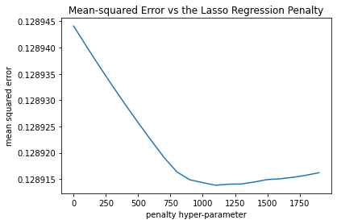

```python
MSEs = [k_fold_average_MSE_lasso_estimate(standardised_X_without_LC50, standardised_LC50, 5, penalty*100) for penalty in range(20)]

plt.ticklabel_format(useOffset=False)
plt.plot([i*100 for i in range(20)], MSEs)
plt.title('Mean-squared Error vs the Lasso Regression Penalty')
plt.xlabel('penalty hyper-parameter')
plt.ylabel('mean squared error')

min_MSE = min(MSEs)  # Find the minimum MSE.
min_lambda = [i*100 for i in range(20)][MSEs.index(min_MSE)]  # Find the penalty corresponding to the minimum MSE.
print('The optimal penalty, to 3 s.f. is', min_lambda, ', with a mean squared error of', round(min_MSE, 3))
```

We can now refine this search for the optimal penalty parameter:

```
The optimal penalty, to 3 s.f. is 1143 , with a mean squared error of 0.12891 .
```

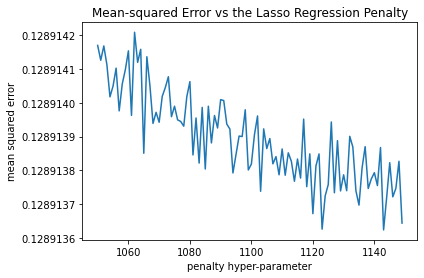

```python
MSEs = [k_fold_average_MSE_lasso_estimate(standardised_X_without_LC50, standardised_LC50, 5, 1050 + penalty) for penalty in range(100)]

plt.ticklabel_format(useOffset=False)
plt.plot([1050 + i for i in range(100)], MSEs)
plt.title('Mean-squared Error vs the Lasso Regression Penalty')
plt.xlabel('penalty hyper-parameter')
plt.ylabel('mean squared error')

min_MSE = min(MSEs)  # Find the minimum MSE.
min_lambda = [1050 + i for i in range(100)][MSEs.index(min_MSE)]  # Find the penalty corresponding to the minimum MSE.
print('The optimal penalty, to 3 s.f. is', min_lambda, ', with a mean squared error of', round(min_MSE, 5),'.')
```

We note that the 5-fold cross-validated mean-squared error for Lasso regression is marginally better than the mean-squared error of 0.12894 we obtained in ridge regression.

```python
betas_lasso = minimize_ls_huber(standardised_X_without_LC50, standardised_LC50, min_lambda, n_iters=10000, step_size=1e-3)
```

```python
is_R_squared = find_R_squared_score(standardised_X_without_LC50, standardised_LC50, betas_lasso)
oos_R_squared = find_R_squared_score(standardised_X_test_without_LC50, standardised_LC50_test, betas_lasso)

print(f'The in-sample Lasso regression R^2 score is {is_R_squared}')
print(f'The out-of-sample Lasso regression R^2 score is {oos_R_squared}')
```

```
The in-sample Lasso regression R^2 score is 0.8714446484111451
The out-of-sample Lasso regression R^2 score is 0.8641068464413338
```

### 1.3.2

We now observe the optimal regression coefficients according to each of our models graphically:

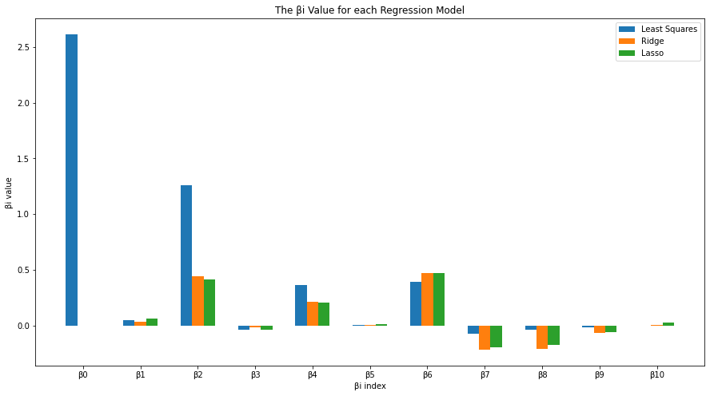

```python
X = [f'β{i}' for i in range(11)]
X_axis = np.arange(len(X))

plt.figure(figsize=(15, 8))
plt.bar(X_axis - 0.2, betas_ml, 0.2, label = 'Least Squares')
plt.bar(X_axis + 0, betas_ridge, 0.2, label = 'Ridge')
plt.bar(X_axis + 0.2, betas_lasso, 0.2, label = 'Lasso')

plt.xticks(X_axis, X)
plt.xlabel("βi index")
plt.ylabel("βi value")
plt.title("The βi Value for each Regression Model")
plt.legend()
plt.show()
```

# Task 2: Classification ^

```python
tumour = pd.read_csv('tumour_samples.csv')
tumour.head()  # Observe the first 5 rows to see how the data is presented.
```

|  | Unnamed: 0 | n1_radius | n1_texture | n1_perimeter | n1_area | n1_smoothness | n1_compactness | n1_concavity | n1_concave_points | n1_symmetry | ... | n3_texture | n3_perimeter | n3_area | n3_smoothness | n3_compactness | n3_concavity | n3_concave_points | n3_symmetry | n3_fractal_dimension | DIAGNOSIS |
| --- | --- | --- | --- | --- | --- | --- | --- | --- | --- | --- | --- | --- | --- | --- | --- | --- | --- | --- | --- | --- | --- |
| 0 | 0 | 10.855170 | 15.248290 | 69.167041 | 359.534878 | 0.105488 | 0.080200 | 0.066410 | 0.034194 | 0.182796 | ... | 18.984557 | 81.443134 | 466.879302 | 0.149080 | 0.200185 | 0.205695 | 0.111592 | 0.335999 | 0.093477 | B |
| 1 | 1 | 10.068958 | 15.532758 | 66.130635 | 330.040665 | 0.099813 | 0.109540 | 0.057583 | 0.023322 | 0.195650 | ... | 22.840293 | 82.133171 | 473.367822 | 0.125478 | 0.330466 | 0.283304 | 0.088021 | 0.312882 | 0.096158 | B |
| 2 | 2 | 12.271409 | 18.100314 | 78.195610 | 421.537832 | 0.105147 | 0.095315 | 0.043317 | 0.031539 | 0.188801 | ... | 26.365608 | 84.598334 | 620.586067 | 0.146766 | 0.118707 | 0.147900 | 0.050402 | 0.291805 | 0.069556 | B |
| 3 | 3 | 10.531733 | 18.452486 | 67.227069 | 340.063033 | 0.086041 | 0.049961 | 0.049709 | 0.011046 | 0.203093 | ... | 24.385385 | 73.296855 | 429.675600 | 0.100060 | 0.143683 | 0.177225 | 0.028111 | 0.287749 | 0.073174 | B |
| 4 | 4 | 12.367686 | 14.399191 | 80.643814 | 460.849710 | 0.106410 | 0.101420 | 0.020806 | 0.021990 | 0.195326 | ... | 19.614305 | 89.910502 | 472.323112 | 0.138135 | 0.276127 | 0.151098 | 0.074396 | 0.345258 | 0.095830 | B |

5 rows × 32 columns

```python
# As before, we clean the data and put it in a form we can easily operate on.
train_data_2 = np.genfromtxt('tumour_samples.csv', delimiter=',')[1:]
X_without_diagnosis = train_data_2[:, 1:-1]
X_without_diagnosis  # Check the general shape and values are correct.
```

```
array([[1.08551705e+01, 1.52482903e+01, 6.91670414e+01, ...,
        1.11591615e-01, 3.35999231e-01, 9.34769693e-02],
       [1.00689581e+01, 1.55327580e+01, 6.61306351e+01, ...,
        8.80205567e-02, 3.12881551e-01, 9.61581754e-02],
       [1.22714095e+01, 1.81003138e+01, 7.81956100e+01, ...,
        5.04019212e-02, 2.91805431e-01, 6.95557587e-02],
       ...,
       [1.11680359e+01, 1.26512029e+01, 6.71023032e+01, ...,
        3.98514766e-02, 2.95526696e-01, 7.05838303e-02],
       [1.17196455e+01, 1.89337834e+01, 7.85568168e+01, ...,
        7.10533297e-02, 3.30223026e-01, 7.95101984e-02],
       [1.18442468e+01, 2.06893496e+01, 7.40578227e+01, ...,
        7.33601833e-02, 2.92209982e-01, 9.19493945e-02]])
```

```python
diagnosis_csv = pd.read_csv('tumour_samples.csv', usecols=['DIAGNOSIS'])
diagnosis_list = list(diagnosis_csv['DIAGNOSIS'])

diagnosis = np.array([0 if y == 'B' else 1 for y in diagnosis_list])  # Make our classifiers numeric.
```

```python
# Shuffle the rows and columns of X, incase there is some sort of correlation that will affect our 5-fold cross-validation.
p = np.random.RandomState(seed=81).permutation(len(diagnosis)) # set a seed so the data and analysis is repeatable.
X_without_diagnosis = X_without_diagnosis[p]
diagnosis = diagnosis[p]
```

```python
standardised_X_without_diagnosis =  standardise(X_without_diagnosis)  # Standardise the training data since kNN classification uses distances.
```

## 2.1 ^

### 2.1.1

The k-Nearest Neighbours algorithm can be used both for classification and regression. Having standardised our data so that each column (equivalently, each feature) has a mean of zero and a variance of one, we can calculate the distance of a given test data point $x$ to all other points in the training data set. We then find the *k* points closest to $x$ and assign the new point $x$ to the majority class of the *k* nearest points. In this notebook we will work with the Euclidean distance

$$ d(\boldsymbol p, \boldsymbol q) = \sqrt{\sum_{i=1}^D{(q_i-p_i)^2}} \, , $$

where $\boldsymbol p$ and $\boldsymbol q$ are the two points in our $D$-dimensional Euclidean space.

```python
def euclidian_distance(p, q):
    '''
    Find the Euclidean distance between two points p and q.
    '''
    return np.sqrt(np.sum((p-q)**2, axis=1))
```

```python
def k_neighbours(X_train, X_test, k):
    '''
    Find the indices of the k-nearest neighbours in the training data to each point in the testing data.
    '''
    dist = []
    neigh_ind = []

    point_dist = [euclidian_distance(x_test, X_train) for x_test in X_test]  # Compute the distance from each point in X_test to all points in X_train.

    for row in point_dist:
        enum_neigh = enumerate(row)
        sorted_neigh = sorted(enum_neigh, key=lambda x: x[1])[:k]

        ind_list = [tup[0] for tup in sorted_neigh]  # Determine the indices of the k training points closest to each test point.
        dist_list = [tup[1] for tup in sorted_neigh]

        dist.append(dist_list)
        neigh_ind.append(ind_list)

    return np.array(neigh_ind)
```

```python
def predict(X_train, y_train, X_test, k):
    '''
    Predict the classification for each data point in the test data, given the training data and its classification.
    '''
    neighbours = k_neighbours(X_train, X_test, k)
    y_pred = np.array([np.argmax(np.bincount(y_train[neighbour])) for neighbour in neighbours])  # Choose the label with the most number of occurences.
    return np.array(y_pred)
```

```python
def kNN_predict(X, y, k, number_of_folds=5):
    '''
    Implement 5-fold cross-validation on the training data to find the optimal value of the hyper-parameter k.
    '''
    N, D = X.shape
    n_neighbours = k
    folds = folds_func(y, number_of_folds)
    y_prediction = np.zeros(shape= (N - N%number_of_folds))

    if number_of_folds == 1:
        y_pred = predict(X, y, X, k)
        y_prediction += y_pred

    else:
        for i in range(len(folds)):
            test_indices = folds[i]
            train_indices = list(set(range(len(y))) - set(test_indices))

            X_train = X[train_indices][:]
            y_train = y[train_indices]
            X_test = X[test_indices][:]
            y_test = y[test_indices]

            y_pred = predict(X_train, y_train, X_test, k)
            y_prediction[test_indices] += y_pred

    return y_prediction
```

```python
def number_correct_predictions(X, y, k, number_of_folds=5):
    '''
    Count the number of correct predictions for a particular k and 5-fold cross-validation.
    '''
    correct = 0
    kNN_prediction = kNN_predict(X, y, k, number_of_folds)
    for i in range(len(y) - len(y)%number_of_folds):
        if y[i] == kNN_prediction[i]:
            correct += 1

    return correct
```

```python
def kNN_score(X, y, k, number_of_folds=5):
    '''
    Find the fraction of predictions that are correct for a particular k and 5-fold cross-validation.
    '''
    return number_correct_predictions(X, y, k, number_of_folds)/(len(y) - len(y)%number_of_folds)
```

```python
score = [kNN_score(standardised_X_without_diagnosis, diagnosis, k, number_of_folds=5) for k in range(1, 50)]

max_score = max(score)
print(f'The best score is {round(max_score, 4)} and is acheived when k = {score.index(max_score) + 1}.')
```

```
The best score is 0.9977 and is acheived when k = 1.
```

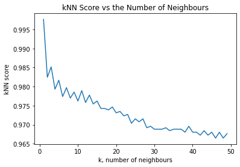

```python
plt.ticklabel_format(useOffset=False)
plt.plot([k for k in range(1, 50)], score)
plt.title('kNN Score vs the Number of Neighbours')
plt.xlabel('k, number of neighbours')
plt.ylabel('kNN score')
plt.show()
```

It is clear from the above plot that k = 1 is our optimal parameter and the score decreases as the number of neighbours in the kNN algorithm increases.

### 2.1.2

We now retrain the model on our entire training data set, using the optimal value of the hyper-parameter k found above, and investigate its success in classifying unseen data.

```python
k = score.index(max_score) + 1
```

```python
tumour_test = pd.read_csv('tumour_test.csv')
tumour_test.head()
```

|  | Unnamed: 0 | n1_radius | n1_texture | n1_perimeter | n1_area | n1_smoothness | n1_compactness | n1_concavity | n1_concave_points | n1_symmetry | ... | n3_texture | n3_perimeter | n3_area | n3_smoothness | n3_compactness | n3_concavity | n3_concave_points | n3_symmetry | n3_fractal_dimension | DIAGNOSIS |
| --- | --- | --- | --- | --- | --- | --- | --- | --- | --- | --- | --- | --- | --- | --- | --- | --- | --- | --- | --- | --- | --- |
| 0 | 0 | 13.40 | 20.52 | 88.64 | 556.7 | 0.11060 | 0.14690 | 0.14450 | 0.08172 | 0.2116 | ... | 29.66 | 113.30 | 844.4 | 0.15740 | 0.38560 | 0.51060 | 0.20510 | 0.3585 | 0.11090 | M |
| 1 | 1 | 13.21 | 25.25 | 84.10 | 537.9 | 0.08791 | 0.05205 | 0.02772 | 0.02068 | 0.1619 | ... | 34.23 | 91.29 | 632.9 | 0.12890 | 0.10630 | 0.13900 | 0.06005 | 0.2444 | 0.06788 | B |
| 2 | 2 | 14.02 | 15.66 | 89.59 | 606.5 | 0.07966 | 0.05581 | 0.02087 | 0.02652 | 0.1589 | ... | 19.31 | 96.53 | 688.9 | 0.10340 | 0.10170 | 0.06260 | 0.08216 | 0.2136 | 0.06710 | B |
| 3 | 3 | 14.26 | 18.17 | 91.22 | 633.1 | 0.06576 | 0.05220 | 0.02475 | 0.01374 | 0.1635 | ... | 25.26 | 105.80 | 819.7 | 0.09445 | 0.21670 | 0.15650 | 0.07530 | 0.2636 | 0.07676 | B |
| 4 | 4 | 13.03 | 18.42 | 82.61 | 523.8 | 0.08983 | 0.03766 | 0.02562 | 0.02923 | 0.1467 | ... | 22.81 | 84.46 | 545.9 | 0.09701 | 0.04619 | 0.04833 | 0.05013 | 0.1987 | 0.06169 | B |

5 rows × 32 columns

```python
test_data_2 = np.genfromtxt('tumour_test.csv', delimiter=',')[1:]
X_test_without_diagnosis = test_data_2[:, 1:-1]
```

```python
diagnosis_csv_test = pd.read_csv('tumour_test.csv', usecols=['DIAGNOSIS'])
diagnosis_list_test = list(diagnosis_csv_test['DIAGNOSIS'])

diagnosis_test = np.array([0 if y == 'B' else 1 for y in diagnosis_list_test])
```

```python
standardised_X_test_without_diagnosis = X_test_without_diagnosis
mus_and_stdvs = get_mus_and_stdvs(X_without_diagnosis)

for j in range(X_test_without_diagnosis.shape[1]):
    for i in range(X_test_without_diagnosis.shape[0]):
        standardised_X_test_without_diagnosis[i, j] = (X_test_without_diagnosis[i, j] - mus_and_stdvs[j][0] ) / mus_and_stdvs[j][1]
```

Having standardised the test data set, using the means and standard deviations of the corresponding columns in the training data set, we can determine the accuray of our kNN model on the unseen test data set.

```python
def accuracy(true, prediction):
    '''
    Find the accuracy of a set of predictions for a given set of true values.
    '''
    correct = 0

    for i in range(len(true)):
        if prediction[i] == true[i]:
            correct += 1

    accuracy = correct/len(true)
    return accuracy
```

```python
diagnosis_predictions = predict(standardised_X_without_diagnosis, diagnosis, standardised_X_without_diagnosis, 1)
diagnosis_test_predictions = predict(standardised_X_without_diagnosis, diagnosis, standardised_X_test_without_diagnosis, 1)

train_accuracy = accuracy(diagnosis, diagnosis_predictions)
test_accuracy = accuracy(diagnosis_test, diagnosis_test_predictions)

print(f'The model has an accuracy of {train_accuracy} when used to classify each data point in the seen training data set.')
print(f'The model has an accuracy of {test_accuracy} when used to classify each data point in the unseen test data set.')
```

```
The model has an accuracy of 1.0 when used to classify each data point in the seen training data set.
The model has an accuracy of 1.0 when used to classify each data point in the unseen test data set.
```

This is clearly the best accuracy we could hope for and shows our k-Nearest Neighbours model with k = 1 performs well on both the data it was trained on (although with k = 1 this is self evident) and the unseen test data.

However, whilst an accuracy of 1.0 on the unseen test data is optimal, it should be noted that this accuracy is not unique. In fact, we obtain an accuracy of 1.0 on the unseen test data set for k = 1, k = 2 and k = 3.

```python
for k in range(1, 6):
    print(f'The accuracy for k = {k} is {accuracy(diagnosis_test, predict(standardised_X_without_diagnosis, diagnosis, standardised_X_test_without_diagnosis, k))}')
```

```
The accuracy for k = 1 is 1.0
The accuracy for k = 2 is 1.0
The accuracy for k = 3 is 1.0
The accuracy for k = 4 is 0.975
The accuracy for k = 5 is 0.975
```

```python
for k in range(1, 6):
    print(f'The accuracy for k = {k} is {accuracy(diagnosis, predict(standardised_X_without_diagnosis, diagnosis, standardised_X_without_diagnosis, k))}')
```

```
The accuracy for k = 1 is 1.0
The accuracy for k = 2 is 0.9996102883865939
The accuracy for k = 3 is 0.9996102883865939
The accuracy for k = 4 is 0.9863600935307872
The accuracy for k = 5 is 0.9867498051441933
```

This further suggests that the data points in the unseen test data set are very distinctly in either of the model's respective classes and not near their boundry.

## 2.2 ^

We now train a random forest classifier on the data set, employing cross-entropy as the information criterion for the splits in the decision tree.

To determine $j$ and $s$ at each split node, we search for $j$ and $s$ that minimizes the weighted sum of *Cross-Entropy* of the left side samples and right side samples:

$$CE(\boldsymbol y; j, s) = p_l \times CE(\boldsymbol y_l) + p_r \times CE(\boldsymbol y_r)$$

where $p_l$ and $p_r$ are, respectively, the cumulative weights of samples on the left and on the right, while $CE(\boldsymbol y)$ is defined as:

$$ \text{CE}(\boldsymbol y) = - \sum_{i=1}^Q \mathbb P (y = c_i) \cdot \log(\mathbb P (y = c_i)) $$

where $c_i$ is the i-th class out of $Q$ distinct classes, so $\mathbb P (y = c_i)$ reads the weight of the class $i$ in the current sample $\boldsymbol y$.

In doing this minimisation, with an unseen data point we can traverse successive splits in the random forest and attain a prediction for the classification of this unseen data point, based on the path it took down each decision tree. We will optimise our random forest based on the hyper-parameters: number of decision trees and depth of trees. One might naively think that the optimal values for each of these hyper-parameters would be as high as possible but this is not the case for a more general model: we do not want to overfit our model to the training data rendering it ineffective for unseen data sets of the same variety.

```python
training_weights = np.ones_like(diagnosis) / len(diagnosis)  # Initialise the initial weights to all be equal and sum to one.
```

We want to allow the code to consider samples with different weights to maintain generality, hence introduce an additional argument called sample_weights in the cross-entropy index function.

```python
def ce_index(y, sample_weights):
    """
    Calculate the cross-entropy-index for labels.
    """
    label_weights = {yi: 0 for yi in set(y)}  # Initialize with zero for each distinct label.
    for yi, wi in zip(y, sample_weights):
        label_weights[yi] += wi  # Count different labels in  and store in label_weights
    total_weight = sum(label_weights.values())
    ce = 0

    for label, weight in label_weights.items():
        ce -= (weight / total_weight) * np.log(weight/total_weight)

    return ce
```

```python
ce_index(diagnosis, training_weights)  # Check the function is working and not returning any errors.
```

```
0.4482540468603776
```

Next, we define a function to split the data samples based on a feature (column) index and a value. This will be called in later functions. We note that since all of the data is numeric, we do not need to implement an additional method for splitting categorical data.

```python
def split_samples(X, y, sample_weights, column, value):
    """
    Return the split of data whose column-th feature is less than value.
    """
    left_mask = (X[:, column] < value)

    X_left, X_right = X[left_mask, :], X[~left_mask, :]
    y_left, y_right = y[left_mask], y[~left_mask]
    w_left, w_right  = sample_weights[left_mask], sample_weights[~left_mask]

    return (X_left, X_right), (y_left, y_right), (w_left, w_right)
```

For a given feature index, we need to estimate the best value $s$ to use as threshold. We need to implement the function that searches for $s$ and minimizes the *ce-index*. We do this by calling our previously defined functions `split_samples` and `ce_index`.

```python
def ce_split_value(X, y, sample_weights, column):
    """
    Calculate the ce-index based on `column` with the split that minimizes the ce-index.
    """
    unique_vals = np.unique(X[:, column])
    ce_index_val, threshold = np.inf, None

    # Split the values of the i-th feature and calculate the cost.
    for value in unique_vals:
        (X_l, X_r), (y_l, y_r), (w_l, w_r) = split_samples(X, y, sample_weights, column, value)

        p_left = sum(w_l)/(sum(w_l) + sum(w_r))
        p_right = 1 - p_left
        new_cost = p_left * ce_index(y_l, w_l) + p_right * ce_index(y_r, w_r)
        if new_cost < ce_index_val:
            ce_index_val, threshold = new_cost, value

    return ce_index_val, threshold
```

```python
ce_split_value(X_without_diagnosis, diagnosis, training_weights, 29)  # Check the function does not return an error.
```

```
(0.41808091272230413, 0.09244381077950904)
```

We now choose the best feature to split by calling the function `ce_split_value` for each feature.

```python
def ce_split(X, y, sample_weights, printing=False):
    """
    Choose the best feature to split according to criterion - we want the smallest ce-index value.
    """
    min_ce_index, split_column, split_val = np.inf, None, 0  # split_column = None means there is no valid split at the current node.

    for column in range(X.shape[1]):
        if len(np.unique(X[:, column])) < 2:  # Skip column if samples are not seperable by that column.
            continue
        ce_index, val = ce_split_value(X, y, sample_weights, column)
        if ce_index < min_ce_index:
            min_ce_index, split_column, split_val = ce_index, column, val
            if printing:
                print('Current minimum Cross-Entropy index =', ce_index)

    return split_column, split_val
```

```python
col, val = ce_split(X_without_diagnosis, diagnosis, training_weights, printing=True)  # See how the function runs and check what best feature split is.
col_name = (pd.DataFrame(pd.read_csv('tumour_samples.csv')).columns[1:])[col]

print(f'The best column to split, according to cross-entropy, is column {col} ({col_name}), with a value of {val}.')
```

```
Current minimum Cross-Entropy index = 0.24503181512053404
Current minimum Cross-Entropy index = 0.22913904990185746
Current minimum Cross-Entropy index = 0.2229593186376782
Current minimum Cross-Entropy index = 0.19313063083083065
Current minimum Cross-Entropy index = 0.18015319253225462
The best column to split, according to cross-entropy, is column 22 (n3_perimeter), with a value of 117.3317394573687.
```

We need a function that returns the label which appears the most in our label variable y.

```python
def majority_vote(y, sample_weights):
    """
    Return the label which appears the most in y.
    """
    majority_label = {yi: 0 for yi in set(y)}

    for yi, wi in zip(y, sample_weights):
        majority_label[yi] += wi

    return max(majority_label, key=majority_label.get)
```

```python
majority_vote(diagnosis, training_weights) # Recall that 0 = benign, 1 = malignant.
```

```
0
```

We can now build the decision tree by using `ce_split` to find the best feature to split the data X and `split_samples` to get sub-trees.

```python
def build_tree(X, y, sample_weights, feature_names, depth, max_depth=3, min_samples_leaf=2):
    """
    Build the decision tree according to the data.
    Returns:
      (dict): a dict denoting the decision tree (binary-tree). Each node has seven attributes:
        1. 'feature_name': The column name of the split.
        2. 'feature_index': The column index of the split.
        3. 'value': The value used for the split.
        4. 'majority_label': For leaf nodes, this stores the dominant label. Otherwise, it is None.
        5. 'left': The left sub-tree with the same structure.
        6. 'right' The right sub-tree with the same structure.
    """
    # Include a clause for the cases where (i) no feature, (ii) all labels are the same, (iii) depth exceed, or (iv) X is too small.
    if len(np.unique(y))==1 or depth>=max_depth or len(X)<=min_samples_leaf:
        return {'majority_label': majority_vote(y, sample_weights)}

    split_index, split_val = ce_split(X, y, sample_weights, printing=False)

    if split_index is None:
        return {'majority_label': majority_vote(y, sample_weights)}  # If no valid split at this node, use majority vote.

    (X_l, X_r), (y_l, y_r), (w_l, w_r) = split_samples(X, y, sample_weights, split_index, split_val)

    return {
      'feature_name': feature_names[split_index],
      'feature_index': split_index,
      'value': split_val,
      'majority_label': None,
      'left': build_tree(X_l, y_l, w_l, feature_names, depth + 1, max_depth, min_samples_leaf),
      'right': build_tree(X_r, y_r, w_r, feature_names, depth + 1, max_depth, min_samples_leaf)
    }
```

We define a wrapper function `train` to call this `build_tree` function with the appropriate arguments.

```python
def train(X, y, sample_weights=None):
    """
    Build the decision tree according to the training data.
    """
    if sample_weights is None:
        sample_weights = np.ones(X.shape[0]) / X.shape[0]  # If the sample weights are not provided we assume the samples have uniform weights.
    else:
        sample_weights = np.array(sample_weights) / np.sum(sample_weights)

    feature_names = list(pd.DataFrame(pd.read_csv('tumour_samples.csv')).columns[1:])
    return build_tree(X, y, sample_weights, feature_names, depth=1)
```

```python
tree = train(X_without_diagnosis, diagnosis, sample_weights=None)
```

```python
tree  # Observe that our function is working and displaying properly.
```

```
{'feature_name': 'n3_perimeter',
 'feature_index': 22,
 'value': 117.3317394573687,
 'majority_label': None,
 'left': {'feature_name': 'n3_concave_points',
  'feature_index': 27,
  'value': 0.16258549303344122,
  'majority_label': None,
  'left': {'majority_label': 0},
  'right': {'majority_label': 1}},
 'right': {'feature_name': 'n3_concave_points',
  'feature_index': 27,
  'value': 0.12828320795625361,
  'majority_label': None,
  'left': {'majority_label': 1},
  'right': {'majority_label': 1}}}
```

We now want to use this fitted decision tree to make predictions for our unseen test data set. We first define a function `classify` that takes each single data point `x` as an argument. We write a wrapper function `predict` that calls this classify function.

```python
def classify(tree, x):
    """
    Classify a single sample with the fitted decision tree.
    """
    if tree['majority_label'] is not None:
        return tree['majority_label']

    else:
        if x[tree['feature_index']] < tree['value']:
            return classify(tree['left'], x)
        else:
            return classify(tree['right'], x)
```

```python
def predict(tree, X):
    """
    Predict classification results for X.
    """
    if X.shape[0] == 1:
        return classify(tree, X)
    else:
        return np.array([classify(tree, x) for x in X])
```

To evaluate how well the tree can generalise to unseen test data set, we define a function that computes the mean accuracy.

```python
def tree_score(tree, X_test, y_test):
    '''
    Find the mean accuracy of the prediction.
    '''
    y_pred = predict(tree, X_test)
    return np.mean(y_pred==y_test)
```

```python
print('Training accuracy:', tree_score(tree, X_without_diagnosis, diagnosis))
print('Test accuracy:', tree_score(tree, X_test_without_diagnosis, diagnosis_test))
```

```
Training accuracy: 0.9672642244738893
Test accuracy: 0.825
```

Whilst this clearly suggests our tree is capable of classifying the data (in that it has a higher success probability than random selection), the current hyper-parameters are most likely not currently optimised. As such, we will now embed the above formulation of an individual classification tree into an ensemble model called a random forest.

We will apply bootstrapping and aggregating methods for multiple decision trees upon two levels. Firstly, we will bootstrap on the training instances: each model is trained on a random-sample (with replacement) from the training-instances. Secondly, we will explore multiple depths for each individual tree, using an ensemble of models to predict our optimal variable. As such, this design leaves us with two hyper-parameters to optimise: `B`, the number of decision trees and `max_depth`, the maximum depth of each tree.

```python
def ce_split_rf(n_features, X, y, sample_weights):
    """
    Choose the best feature to split according to criterion - we want the smallest ce-index value.
    """
    columns = np.random.RandomState(seed=99).choice([i for i in range(X.shape[1])], n_features, replace=False)
    min_ce_index, split_column, split_val = np.inf, 0, 0

    for column in columns:
        if len(np.unique(X[:, column])) < 2:  # Skip column if samples are not seperable by that column.
            continue
        ce_index, val = ce_split_value(X, y, sample_weights, column)  # Search for the best splitting value for the given column.
        if ce_index < min_ce_index:
            min_ce_index, split_column, split_val = ce_index, column, val

    return min_ce_index, split_column, split_val
```

We can then modify `build_tree` to call `ce_split_rf` instead of `ce_split` as before.

```python
def build_tree_rf(n_features, X, y, sample_weights, feature_names, depth,  max_depth=10, min_samples_leaf=2):
    """
    Build the decision tree according to the data.
    Returns:
      (dict): a dict denoting the decision tree (binary-tree). Each node has seven attributes:
        1. 'feature_name': The column name of the split.
        2. 'feature_index': The column index of the split.
        3. 'value': The value used for the split.
        4. 'majority_label': For leaf nodes, this stores the dominant label. Otherwise, it is None.
        5. 'left': The left sub-tree with the same structure.
        6. 'right' The right sub-tree with the same structure.
    """
    # Include a clause for the cases where (i) all lables are the same, (ii) depth exceed (iii) X is too small.
    if len(np.unique(y)) == 1 or depth>=max_depth or len(X)<=min_samples_leaf:
        return {'majority_label': majority_vote(y, sample_weights)}

    else:
        ce, split_index, split_val = ce_split_rf(n_features, X, y, sample_weights)

        # If the cross-entropy is infinity, it means that samples are not seperable by the sampled features.
        if ce == np.inf:
            return {'majority_label': majority_vote(y, sample_weights)}

        (X_l, X_r), (y_l, y_r), (w_l, w_r) = split_samples(X, y, sample_weights, split_index, split_val)

        return {
            'feature_name': feature_names[split_index],
            'feature_index': split_index,
            'value': split_val,
            'majority_label': None,
            'left': build_tree_rf(n_features, X_l, y_l, w_l, feature_names, depth + 1, max_depth, min_samples_leaf),
            'right': build_tree_rf(n_features, X_r, y_r, w_r, feature_names, depth + 1, max_depth, min_samples_leaf)
        }
```

We can now write the training function that calls `build_tree_rf` and constructs multiple decision trees, each operating on a subset of samples (with replacement).

```python
def train_rf(B, n_features, X, y, sample_weights=None, max_depth=2):
    """
    Build the decision tree according to the training data.
    """
    if sample_weights is None:
        sample_weights = np.ones(X.shape[0]) / X.shape[0]  # If the sample weights are not provided we assume the samples have uniform weights.
    else:
        sample_weights = np.array(sample_weights) / np.sum(sample_weights)  # Normalise the vector of weights.

    N = X.shape[0]
    training_indices = np.arange(N)
    trees = []
    feature_names = list(pd.DataFrame(pd.read_csv('tumour_samples.csv')).columns[1:])

    for _ in range(B):
        sample = np.random.choice(training_indices, N, replace=True)
        X_sample = X[sample, :]
        y_sample = y[sample]
        w_sample = sample_weights[sample]
        tree = build_tree_rf(n_features, X_sample, y_sample, w_sample, feature_names, depth=1, max_depth=max_depth)
        trees.append(tree)

    return trees
```

We can now write a prediction function which aggregates the decision from all decision trees and returns the class with highest probability.

```python
def aggregate(decisions):
    '''
    Aggregate the decisions and find the class with the highest probability.
    '''
    count = defaultdict(int)
    for decision in decisions:
        count[decision] += 1
    return max(count, key=count.get)
```

```python
def predict_rf(rf, X):
    """
    Predict classification results for X.
    """
    if len(X.shape) == 1:
        return aggregate([classify(tree, X) for tree in rf])
    else:
        return np.array([aggregate([classify(tree, x) for tree in rf]) for x in X])
```

```python
def rf_score(rf, X_test, y_test):
    '''
    Find the mean accuracy of the prediction.
    '''
    y_pred = predict_rf(rf, X_test)
    return np.mean(y_pred==y_test)
```

From the lecture notes we know that for classification problems we should set the number of predictors in the model to be approximately (total number of predictors)/3. We initialise this value now:

```python
n_features = X_without_diagnosis.shape[1] // 3
```

We can now train a trial random forest to check if we are encountering any errors.

```python
rf = train_rf(3, n_features, X_without_diagnosis, diagnosis, max_depth=3)
rf
```

```
[{'feature_name': 'n3_concave_points',
  'feature_index': 27,
  'value': 0.1514703848919555,
  'majority_label': None,
  'left': {'feature_name': 'n3_area',
   'feature_index': 23,
   'value': 943.286777168352,
   'majority_label': None,
   'left': {'majority_label': 0},
   'right': {'majority_label': 1}},
  'right': {'feature_name': 'n3_area',
   'feature_index': 23,
   'value': 902.9358361338257,
   'majority_label': None,
   'left': {'majority_label': 1},
   'right': {'majority_label': 1}}},
 {'feature_name': 'n3_area',
  'feature_index': 23,
  'value': 928.7707888616322,
  'majority_label': None,
  'left': {'feature_name': 'n3_concave_points',
   'feature_index': 27,
   'value': 0.16421107435561416,
   'majority_label': None,
   'left': {'majority_label': 0},
   'right': {'majority_label': 1}},
  'right': {'feature_name': 'n3_concave_points',
   'feature_index': 27,
   'value': 0.14660935178752793,
   'majority_label': None,
   'left': {'majority_label': 1},
   'right': {'majority_label': 1}}},
 {'feature_name': 'n3_area',
  'feature_index': 23,
  'value': 928.7707888616322,
  'majority_label': None,
  'left': {'feature_name': 'n3_concave_points',
   'feature_index': 27,
   'value': 0.16421107435561416,
   'majority_label': None,
   'left': {'majority_label': 0},
   'right': {'majority_label': 1}},
  'right': {'feature_name': 'n3_concave_points',
   'feature_index': 27,
   'value': 0.14628375372076738,
   'majority_label': None,
   'left': {'majority_label': 1},
   'right': {'majority_label': 1}}}]
```

It all looks okay! We can now define a random forrest mean-squared error function that uses the same 5-fold cross-validation as before to eventually determine the optimal values for our hyper-parameters: number of trees and maximum tree depth.

```python
def B_tree_average_MSE_rf(X, y, B, d, k=5):
    '''
    Find the average random forest mean-squared error for a particular number of decision trees and depth.
    '''

    folds = folds_func(y, k)
    MSEs = []

    for i in range(len(folds)):
        test_indices = folds[i]
        train_indices = list(set(range(len(y))) - set(test_indices))

        X_train = X[train_indices][:]
        y_train = y[train_indices]
        X_test = X[test_indices][:]
        y_test = y[test_indices]

        rf = train_rf(B, n_features, X_train, y_train, sample_weights=None, max_depth=d)
        score = rf_score(rf, X_test, y_test)
        MSEs.append(score)

    average_MSE = sum(MSEs)/k
    return average_MSE
```

```python
def best_Bd_pair(X, y, k, B_range, d_range):
    '''
    Find the optimal values for the hyper-parameters B and d, according to the average mean-squared error a model with these parameters returns.
    '''
    B_scores = np.zeros((len(d_range), len(B_range)))

    for j, B in enumerate(B_range):
        for i, d in enumerate(d_range):
            B_scores[i, j] = B_tree_average_MSE_rf(X, y, B, d, k=5)
            print(f'Cross-Validated Accuracy at depth={d}, #trees={B}: {B_scores[i, j]:8f}')

    best_B_index = np.argwhere(B_scores==B_scores.max())
    print(B_scores)
    print(best_B_index)
    return (d_range[best_B_index[0][0]], B_range[best_B_index[0][1]])
```

```python
optimal_Bd_pair = best_Bd_pair(X_without_diagnosis, diagnosis, 5, np.array([1, 2, 3]), np.array([1, 2, 3]))
```

```
Cross-Validated Accuracy at depth=1, #trees=1: 0.834698
Cross-Validated Accuracy at depth=2, #trees=1: 0.950487
Cross-Validated Accuracy at depth=3, #trees=1: 0.961793
Cross-Validated Accuracy at depth=1, #trees=2: 0.834698
Cross-Validated Accuracy at depth=2, #trees=2: 0.953216
Cross-Validated Accuracy at depth=3, #trees=2: 0.964912
Cross-Validated Accuracy at depth=1, #trees=3: 0.834698
Cross-Validated Accuracy at depth=2, #trees=3: 0.945419
Cross-Validated Accuracy at depth=3, #trees=3: 0.971930
[[0.83469786 0.83469786 0.83469786]
 [0.95048733 0.95321637 0.9454191 ]
 [0.96179337 0.96491228 0.97192982]]
[[2 2]]
```

We therefore see that our optimal hyper-parameters are:

```
Number of decision trees = 3
Maximum tree depth = 3
```

It is interesting to note that the maximum depth is a far more influential hyper-parameter in determining the accuracy of a random forrest compared with the number of trees. This makes sense because low maximum depth values often lead to the model underfitting the data, potentially wrongly classifying borderline data points. Additionally, the optimal number of decision trees being 3 as opposed to 2 or 1 implies that B = 3 lead to the model arbitrarily choosing decision trees that were more effective at modelling the entire data set. In subsequent iterations, it would be perfectly feasible for B = 1 or B = 2 to be the optimal number of trees (although less likely than 3, simply due to the reduction in variance).

### 2.2.2

We can now define a function to compute the confusion matrix for a given random forest and input test data set. The confusion matrix allows is a summary of prediction results on a classification problem and defined as follows:

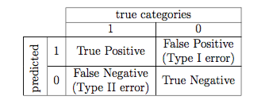

```python
def conf_matrix(rf, X_test, y_test):
    '''
    Find the confusion matrix for a given random forest classification and test data set.
    '''
    y_pred = predict_rf(rf, X_test)
    mat = np.zeros((2, 2))

    for true, pred in zip(y_test, y_pred):
        if true == 1 and pred == 1:
            mat[0, 0] += 1
        elif true == 0 and pred == 0:
            mat[1, 1] += 1
        else:
            mat[true, pred] += 1

    return mat
```

Using the optimal hyper-parameter values found above, we display the confusion matrix for both the training and test data sets:

```python
optimal_rf = train_rf(3, n_features, X_without_diagnosis, diagnosis, max_depth=3)
```

```python
sample_conf_matrix = conf_matrix(optimal_rf, X_without_diagnosis, diagnosis)
test_conf_matrix = conf_matrix(optimal_rf, X_test_without_diagnosis, diagnosis_test)

print('The sample confusion matrix is:')
print(sample_conf_matrix)
print()
print('The test confusion matrix is:')
print(test_conf_matrix)
```

```
The sample confusion matrix is:
[[ 379.   20.]
 [  45. 2122.]]

The test confusion matrix is:
[[68. 30.]
 [ 5. 97.]]
```

We can define some additional functions, based on the confusion matrix, that help us analyse the classification's success.

```python
def recall(mat):
    return mat[0, 0] / (mat[0, 0] + mat[1, 0])

def specificity(mat):
    return mat[1, 1] / (mat[1, 1] + mat[0, 1])

def accuracy(mat):
    return (mat[0, 0] + mat[1, 1])/ np.sum(mat)

def precision(mat):
    return mat[0, 0] / (mat[0, 0] + mat[0, 1])

def fscore(mat):
    return 2 * precision(mat) * recall(mat) / (precision(mat) + recall(mat))
```

We therefore see that for the training data set we have:

```python
print(f'Recall = {round(recall(sample_conf_matrix), 4)}')
print(f'Specificity = {round(specificity(sample_conf_matrix), 4)}')
print(f'Accuracy = {round(accuracy(sample_conf_matrix), 4)}')
print(f'Precision = {round(precision(sample_conf_matrix), 4)}')
print(f'F-Score = {round(fscore(sample_conf_matrix), 4)}')
```

```
Recall = 0.8939
Specificity = 0.9907
Accuracy = 0.9747
Precision = 0.9499
F-Score = 0.921
```

And for the test data set we have:

```python
print(f'Recall = {round(recall(test_conf_matrix), 4)}')
print(f'Specificity = {round(specificity(test_conf_matrix), 4)}')
print(f'Accuracy = {round(accuracy(test_conf_matrix), 4)}')
print(f'Precision = {round(precision(test_conf_matrix), 4)}')
print(f'F-Score = {round(fscore(test_conf_matrix), 4)}')
```

```
Recall = 0.9315
Specificity = 0.7638
Accuracy = 0.825
Precision = 0.6939
F-Score = 0.7953
```

We therefore see that our optimised random forest is a good classifier for both itself and the unseen test data. For the sample confusion matrix, an accuracy of 0.97 suggests that almost all of the sample data can be classified using just three seperations, showing the data to be very seperable. In fact, this could have been anticipated since the kNN optimal hyper-parameter was k = 1, suggesting the data is distinctly clustered into its repective classes. Whilst the accuracy for the unseen test data is lower, given that it is over 80% accurate itself we can ascertain that the random forrest is also an effective classifier of unseen data. In essence, this suggests that the random forest does not overfit or underfit the data. The recall, which measures the true positive rate, is actually higher for the unseen test data than the recall for the sample data. We assume that this is due to the uneven distribution of the data: the sample data has approximately 20% 'Malignant' data points whereas the test data has approximately 38% 'Malignant'. Due to the increased propensity of 'Malignant' data points in the test data, it is more likely they are distinctly in the 'Malignant' region; anomolies are less significant. In addition, this could simply be due to how the data has been collected - it is a possibility that the test data contains very easy to determine 'Malignenet' data points and they are therefore well classified. Despite this 20:80 split of the sample data into 'Benign' and 'Malignant' data points, the sample confusion matrix's specificity (the true negative rate) of 0.99 implies that the model is more successful at predicting 'Benign' tumours (classification 0) and generally has a bias towards making a 'Benign' classification for a data point. This enforces the argument that the 'Malignant' data points in the test data set are easily determined since the test data confusion matrix's specificity is only 0.76.

## 2.3 ^

### 2.3.1

In the final section of this notebook we will train a soft margin linear support vector machine classifier on the sample data set, once again employing 5-fold cross-validation. For support vector machine classification it makes our calculations simpler to classify our prediction variables as -1 and 1 (instead of 0 and 1 as before) and we implemeent this change below:

```python
diagnosis_SVM = np.array([-1.0 if y == 0 else 1.0 for y in diagnosis])
diagnosis_SVM_test = np.array([-1.0 if y == 0 else 1.0 for y in diagnosis_test])
```

```python
standardised_X_without_diagnosis_SVM = np.hstack([np.ones((X_without_diagnosis.shape[0],1)), standardise(X_without_diagnosis)])
standardised_X_test_without_diagnosis_SVM = np.hstack([np.ones((X_test_without_diagnosis.shape[0],1)), standardise(X_test_without_diagnosis)])
```

Support vector machine classification can be intuitively thought of in term of distances: we wish to find the hyper plane through the data that will lead to the greatest distance between the two closest points on either respective side. This is often referred to as finding the 'widest street'. Of couse, perfect data sets, where the data points are seperable in d-dimensional space, rarely exist. We can therefore relax this hard classification to the softer case of imperfect classification, where the introduction of a penalty term penalises violations to the seperation of our hyper-plane. In this softer case, we allow support vector machine classification to make a certain number of mistakes and keep the margin as wide as possible so that other points can still be classified correctly.

Our aim is the minimise the hinge loss function $$ \mathcal L (\boldsymbol w) = \frac{1}{2} \| \boldsymbol w \|^2 + \frac{\lambda}{n} \sum_{i=1}^n \max \bigg( 0, 1-y_i (\boldsymbol w \cdot x_i + b) \bigg) \, . $$ where $\boldsymbol w$ is the vector of weights, $\lambda$ the regularisation parameter, and $b$ the intercept which is included in our `X` as an additional column of $1$'s.

```python
def compute_cost(w, X, y, regul_strength=1e5):
    '''
    Find the value of the cost function for a set of data and its wieghts.
    '''
    n = X.shape[0]
    distances = 1 - y * (X @ w)
    distances[distances < 0] = 0  # Equivalent to max(0, distance).
    hinge = regul_strength * distances.mean()
    return 0.5 * np.dot(w, w) + hinge
```

An effective way to optimize the cost is by using a stochastic gradient descent algorithm. In order to use stochastic gradient descent, we need to implement a function for the cost gradients with respect to $w$.

```python
def calculate_cost_gradient(w, X_batch, y_batch, regul_strength=1e5):
    '''
    Find the gradient of the cost function with respect to w.
    '''
    # If only one example is passed
    if type(y_batch) == np.float64:
        y_batch = np.asarray([y_batch])
        X_batch = np.asarray([X_batch])  # Gives multidimensional array.

    distance = 1 - (y_batch * (X_batch @ w))
    dw = np.zeros(len(w))

    for ind, d in enumerate(distance):
        if max(0, d)==0:
            di = w
        else:
            di = w - (regul_strength * y_batch[ind] * X_batch[ind])
        dw += di

    return dw/len(y_batch)  # Return the average.
```

We can now call both of the two previous functions in `sgd` to update the weights iteratively with a given learning rate $\alpha$. We also implement a stop criterion that ends the learning as soon as the cost function has not changed more than a manually determined percentage. This is to maintain efficiency in our code.

We know that the learning happens through updating the weights according to $$ \boldsymbol w = \boldsymbol w - \alpha \frac{\partial \mathcal L}{\partial \boldsymbol w} $$

where $\frac{\partial \mathcal L}{\partial \boldsymbol w}$ is the gradient of the hinge loss we have computed in the previous cell.

```python
def sgd(X, y, batch_size=16, max_iterations=2000, stop_criterion=0.01, learning_rate=1e-5, regul_strength=1e5, print_outcome=False, graph=False):
    '''
    Implement stochastic gradient descent with a given learning rate.
    '''
    weights = np.zeros(X.shape[1])  # Initialise zero weights
    nth = 0
    prev_cost = np.inf  # Initialise starting cost as infinity
    indices = np.arange(len(y))
    if graph:
        graph_vals = []

    for iteration in range(1, max_iterations):
        np.random.RandomState(seed=64).shuffle(indices)  # Shuffle to prevent repeating update cycles.
        batch_idx = indices[:batch_size]
        X_b, y_b = X[batch_idx], y[batch_idx]
        for xi, yi in zip(X_b, y_b):
            ascent = calculate_cost_gradient(weights, xi, yi, regul_strength)
            weights = weights - (learning_rate * ascent)

        # Visualise the convergence on every 2^n'th iteration.
        if iteration==2**nth or iteration==max_iterations-1:
            cost = compute_cost(weights, X, y, regul_strength)
            if print_outcome:
                print("Iteration is: {}, Cost is: {}".format(iteration, cost))
            if graph:
                graph_vals.append(cost)
            # Stop criterion.
            if abs(prev_cost - cost) < stop_criterion * prev_cost:
                if graph:
                    return graph_vals
                return weights

            prev_cost = cost
            nth += 1

    return weights
```

We can now train the model with our sample data set. We use an arbitrary penalty term since we only wish to observe the general trend of our results at this stage.

```python
w = sgd(standardised_X_without_diagnosis_SVM, diagnosis_SVM, batch_size=32, max_iterations=2000, stop_criterion=0.01, learning_rate=1e-5, regul_strength=1e3, print_outcome=True)
print("Training finished.")
```

```
Iteration is: 1, Cost is: 394.9165052735841
Iteration is: 2, Cost is: 312.31944513047523
Iteration is: 4, Cost is: 243.6398309445334
Iteration is: 8, Cost is: 103.778208154004
Iteration is: 16, Cost is: 86.00477740571208
Iteration is: 32, Cost is: 62.906288573781865
Iteration is: 64, Cost is: 50.04160657813182
Iteration is: 128, Cost is: 42.591081683225724
Iteration is: 256, Cost is: 43.335287532826605
Iteration is: 512, Cost is: 35.569784278266425
Iteration is: 1024, Cost is: 35.4105401087358
Training finished.
```

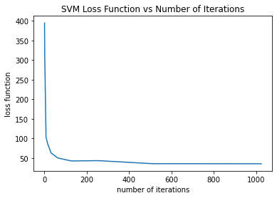

```python
graph_vals = sgd(standardised_X_without_diagnosis_SVM, diagnosis_SVM, batch_size=32, max_iterations=2000, stop_criterion=0.01, learning_rate=1e-5, regul_strength=1e3, print_outcome=False, graph=True)[:]

plt.ticklabel_format(useOffset=False)
plt.plot([2**i for i in range(11)], graph_vals)
plt.title('SVM Loss Function vs Number of Iterations')
plt.xlabel('number of iterations')
plt.ylabel('loss function')
plt.show()
```

We see that there is an immediate and sharp decrease in the loss function, since the initial iterations of gradient descent introduce the most influential changes to the loss function, followed by much less significant changes for higher iterations. This convergence suggests we have found, or are very close to, the minimised loss function.

```python
def score(w, X, y):
    '''
    Find the mean accuracy of our predcitions for a given set of weights.
    '''
    y_preds = np.sign(X @ w)
    return np.mean(y_preds == y)
```

```python
print("Accuracy on train set: {}".format(score(w, standardised_X_without_diagnosis_SVM, diagnosis_SVM)))
print("Accuracy on test set: {}".format(score(w, standardised_X_test_without_diagnosis_SVM, diagnosis_SVM_test)))
```

```
Accuracy on train set: 0.9910366328916602
Accuracy on test set: 0.91
```

Now we repeat the same procedure as above but attempt to find the optimal penalty term through 5-fold cross-validation.

```python
def cross_val_evaluate(X, y, num_folds=5, regul_strength=1e3, printing=False):
    '''
    Implement 5-fold cross-validation to find the accuracy for a particular penalty term, regul_strength.
    '''
    folds = folds_func(y, num_folds)
    train_scores = []
    val_scores = []

    for i in range(len(folds)):
        val_indices = folds[i]
        train_indices = list(set(range(X.shape[0])) - set(val_indices))

        X_train = X[train_indices][:]
        y_train = y[train_indices]
        X_val = X[val_indices][:]
        y_val = y[val_indices]

        # Train the model.
        w = sgd(X_train, y_train, max_iterations=1025, stop_criterion=0.01, learning_rate=1e-5, regul_strength=regul_strength)
        train_score = score(w, X_train, y_train)
        val_score = score(w, X_val, y_val)

        if printing:
            print('Fold', i+1)
            print("Training finished.")
            print("Accuracy on train set #{}: {}".format(i+1, train_score))
            print("Accuracy on validation set #{}: {}".format(i+1, val_score))

        train_scores.append(train_score)
        val_scores.append(val_score)

    return np.mean(train_scores), np.mean(val_scores)
```

By setting `print=True`, we can observe this cross-fold validation in action for a penalty of 1000:

```python
cross_val_evaluate(standardised_X_without_diagnosis_SVM, diagnosis_SVM, 5, 1e3, printing=True)
```

```
Fold 1
Training finished.
Accuracy on train set #1: 0.9902581587920117
Accuracy on validation set #1: 0.98635477582846
Fold 2
Training finished.
Accuracy on train set #2: 0.990745250852411
Accuracy on validation set #2: 0.98635477582846
Fold 3
Training finished.
Accuracy on train set #3: 0.9917194349732099
Accuracy on validation set #3: 0.98635477582846
Fold 4
Training finished.
Accuracy on train set #4: 0.9912323429128105
Accuracy on validation set #4: 0.9922027290448343
Fold 5
Training finished.
Accuracy on train set #5: 0.9902581587920117
Accuracy on validation set #5: 0.98635477582846
```

```
(0.9908426692644909, 0.9875243664717347)
```

```python
def find_best_penalty_SVM(X, y, num_folds, penalty_range, show=False, printing=False):
    '''
    Find the optimal value for the penalty hyper-parameter.
    '''
    penalty_scores = np.zeros((len(penalty_range),))

    for i, penalty in enumerate(penalty_range):
        penalty_scores[i] = cross_val_evaluate(X, y, num_folds, penalty)[1]
        if printing:
            print(f'Cross-Validation Accuracy at penalty = {penalty}: {penalty_scores[i]:.5f}')
    out = (penalty_range[np.argmax(penalty_scores)], max(penalty_scores))
    if show:
        plt.figure(figsize=(15, 8))
        plt.scatter(penalty_range, penalty_scores)
        plt.scatter(out[0], out[1], color='red', marker='x')
        plt.title('Accuracy Score vs Penalty Hyper-parameter')
        plt.xlabel('penalty')
        plt.ylabel('accuracy scores from cross validation')
        plt.show()

    return out
```

```python
find_best_penalty_SVM(standardised_X_without_diagnosis_SVM, diagnosis_SVM, 5, [i for i in range(1, 21)], show=False, printing=True)
```

```
Cross-Validation Accuracy at penalty = 1: 0.83977
Cross-Validation Accuracy at penalty = 2: 0.83977
Cross-Validation Accuracy at penalty = 3: 0.83977
Cross-Validation Accuracy at penalty = 4: 0.83977
Cross-Validation Accuracy at penalty = 5: 0.83977
Cross-Validation Accuracy at penalty = 6: 0.83977
Cross-Validation Accuracy at penalty = 7: 0.83977
Cross-Validation Accuracy at penalty = 8: 0.83977
Cross-Validation Accuracy at penalty = 9: 0.83977
Cross-Validation Accuracy at penalty = 10: 0.83977
Cross-Validation Accuracy at penalty = 11: 0.83977
Cross-Validation Accuracy at penalty = 12: 0.86355
Cross-Validation Accuracy at penalty = 13: 0.86433
Cross-Validation Accuracy at penalty = 14: 0.86511
Cross-Validation Accuracy at penalty = 15: 0.86550
Cross-Validation Accuracy at penalty = 16: 0.95712
Cross-Validation Accuracy at penalty = 17: 0.95750
Cross-Validation Accuracy at penalty = 18: 0.95712
Cross-Validation Accuracy at penalty = 19: 0.98402
Cross-Validation Accuracy at penalty = 20: 0.98402
```

```
(19, 0.9840155945419102)
```

Clearly the accuracy is increasing as the penalty increases. We can plot this trend for increasing ranges for the penalty hyper-parameter to observe how the accuracy varies:

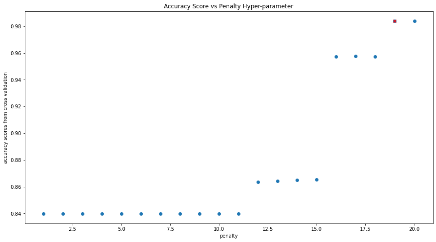

```
(19, 0.9840155945419102)
```

```python
find_best_penalty_SVM(standardised_X_without_diagnosis_SVM, diagnosis_SVM, 5, [i for i in range(1, 21)], show=True, printing=False)
```

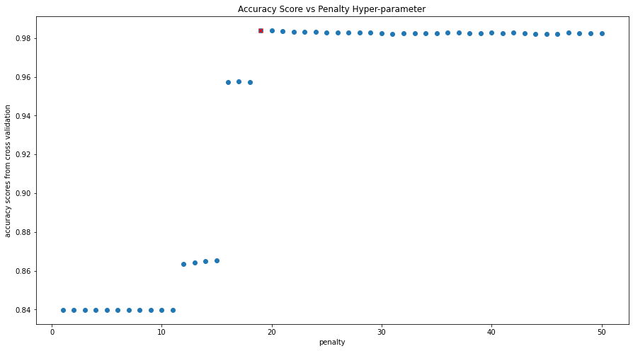

```
(19, 0.9840155945419102)
```

```python
find_best_penalty_SVM(standardised_X_without_diagnosis_SVM, diagnosis_SVM, 5, [i for i in range(1, 51)], show=True, printing=False)
```

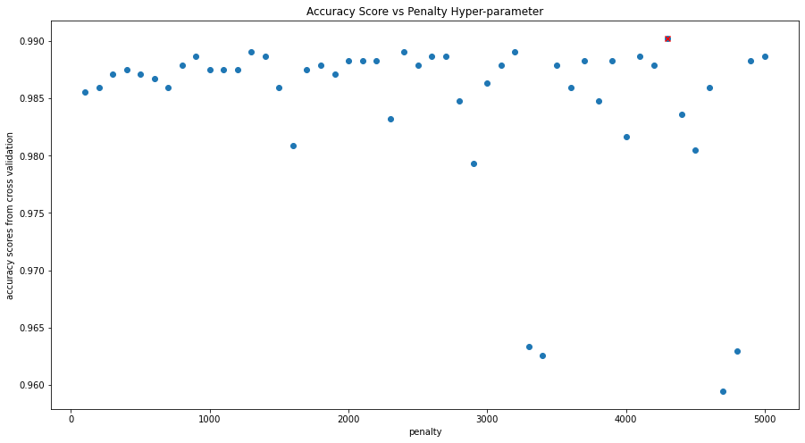

```
(4300, 0.9902534113060428)
```

```python
find_best_penalty_SVM(standardised_X_without_diagnosis_SVM, diagnosis_SVM, 5, [100*i for i in range(1, 51)], show=True, printing=False)
```

### 2.3.2

We now evaluate the performance of our support vector machine classifier as the hardness parameter is varied on our unseen test data set.

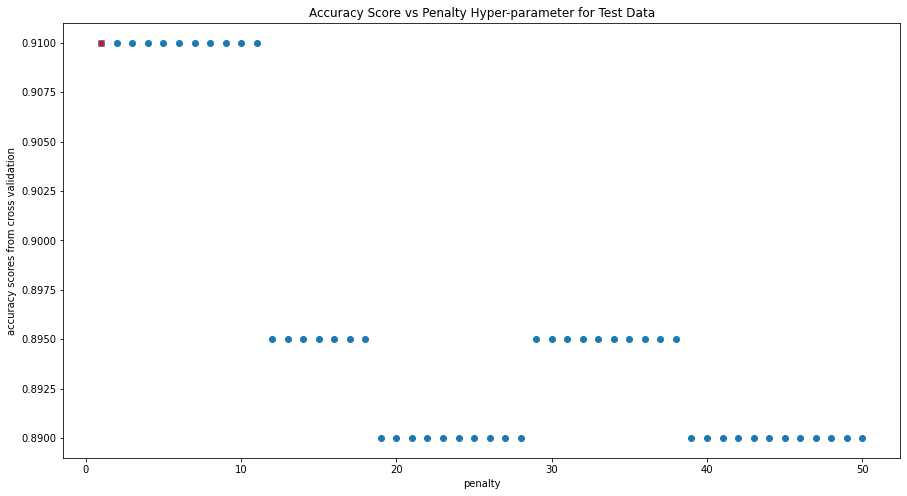

```python
test_scores = []
penalty_range = [i for i in range(1, 51)]

for penalty in penalty_range:
    weights = sgd(standardised_X_without_diagnosis_SVM, diagnosis_SVM, regul_strength=penalty)
    test_scores.append(score(weights, standardised_X_test_without_diagnosis_SVM, diagnosis_SVM_test))

best_test_score = (penalty_range[np.argmax(test_scores)], max(test_scores))

plt.figure(figsize=(15, 8))
plt.scatter(penalty_range, test_scores)
plt.scatter(best_test_score[0], best_test_score[1], color='red', marker='x')
plt.title('Accuracy Score vs Penalty Hyper-parameter for Test Data')
plt.xlabel('penalty')
plt.ylabel('accuracy scores from cross validation')
plt.show()
```

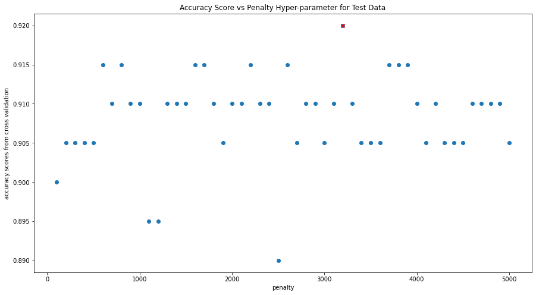

```python
test_scores = []
penalty_range = [100*i for i in range(1, 51)]

for penalty in penalty_range:
    weights = sgd(standardised_X_without_diagnosis_SVM, diagnosis_SVM, regul_strength=penalty)
    test_scores.append(score(weights, standardised_X_test_without_diagnosis_SVM, diagnosis_SVM_test))

best_test_score = (penalty_range[np.argmax(test_scores)], max(test_scores))

plt.figure(figsize=(15, 8))
plt.scatter(penalty_range, test_scores)
plt.scatter(best_test_score[0], best_test_score[1], color='red', marker='x')
plt.title('Accuracy Score vs Penalty Hyper-parameter for Test Data')
plt.xlabel('penalty')
plt.ylabel('accuracy scores from cross validation')
plt.show()
```

```python
best_test_score
```

```
(3200, 0.92)
```

Whilst lower than for the sample data, we see that our support vector machine classifier is still effectve on the test data, and in fact suggests an optimal penalty hyper-parameter of a similar order to the the penalty suggested for the sample data. We can explore this further via receiver operating characteristic curves.

The Receiver Operating Characteristic (ROC) curve aims to capture the model output probabilities (or scores) into the quantification of the model performance. The ROC curve can be constructed by computing True Positive Rate (TPR) and False Positive Rate (FPR) for a range of thresholds. An ideal model would have Area Under the Curve (AUC) of 1, while a model with random decisions would have an AUC of 0.5. This AUC can be computed using the trapezoidal rule.

```python
def logistic(x):
    '''
    Convert each data point to a probability using the logistic function.
    '''
    return 1 / (1 + np.exp(-x))
```

```python
def roc_curve(y_true, y_log):
    """
    Returns:
    auc: area under the curve (AUC).
    tpr_l: a list of true positive rate (TPR) values for each scanned threshold.
    fpr_l: a list of false positive rate (FPR) values for each scanned threshold.
    thresholds: the scanned thresholds sorted descendingly.
    """
    thresholds = reversed(sorted(set(y_log)))  # List the distinct values in y_log and sort descendingly.
    tpr_l, fpr_l = [], []

    for threshold in thresholds:
        y_thresholded = (y_log >= threshold)  # Apply thresholding.

        tp = np.sum(y_true & y_thresholded)  # True positives.
        tn = np.sum((~y_true) & (~y_thresholded))  # True negatives.
        fp = np.sum((~y_true) & y_thresholded)  # False positives.
        fn = np.sum(y_true & (~y_thresholded))  # False negatives.

        tpr = tp / (tp + fn)
        fpr = fp / (tn + fp)
        tpr_l.append(tpr)
        fpr_l.append(fpr)

    auc = np.trapz(tpr_l, fpr_l)  # Compute the area under curve (AUC) using the Trapezoidal rule.
    return auc, tpr_l, fpr_l, thresholds
```

```python
def roc_plots(penalties, X, y, X_test, y_test):
    '''
    Plot the Receiver Operating Characteristic curve for multiple penalty values.
    '''
    aucs = []
    plt.figure(figsize=(15, 15))
    plt.plot([0, 1], [0, 1], 'r--')

    for penalty in penalties:
        w = sgd(X, y, regul_strength=penalty)
        y_pred = X_test @ w

        y_log = logistic(y_pred)
        boolean_y_test = np.array([int(y) if y > 0 else 0 for y in y_test])  # Return to boolean form.
        auc, tpr, fpr, th = roc_curve(boolean_y_test, y_log)
        aucs.append(auc)

        plt.title('Receiver Operating Characteristic Curve', size=20)
        ax = plt.subplot(111)
        plt.plot(fpr, tpr, label=f'penalty = {penalty}, AUC = {auc}')
        box = ax.get_position()
        ax.set_position([box.x0, box.y0 + box.height * 0.1, box.width, box.height*0.9])

        plt.ylabel('TPR', size=20)
        plt.xlabel('FPR', size=20)

    max_ind = np.argmax(aucs)  # Get the best auc and penalty.
    penalty_max = penalties[max_ind]
    m = np.max(aucs)
    print(f'The optimal penalty is {penalty_max} with an area under the curve of {round(m, 5)}.')

    ax.legend(loc='upper center', bbox_to_anchor=(0.5, -0.5), fancybox=True, shadow=True, ncol=6)
    ax.legend().set_visible(False)
    handles, labels = ax.get_legend_handles_labels()
    plt.show()

    axe = plt.subplot()
    axe.legend(handles, labels, ncol=6, loc='upper center')  # Show the legend.
    plt.axis('off')
    ax.legend().set_visible(False)
    plt.show()

    return (penalty_max, m)
```

```
The optimal penalty is 4300 with an area under the curve of 0.99924.
```

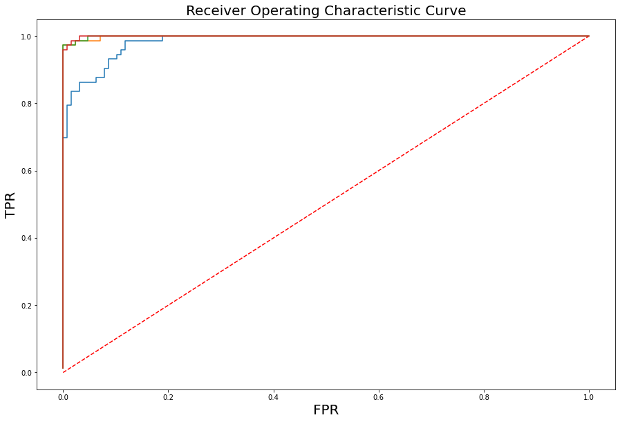

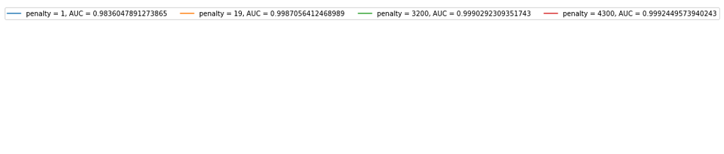

```
(4300, 0.9992449573940243)
```

```python
roc_plots(np.array([1, 19, 3200, 4300]), standardised_X_without_diagnosis_SVM, diagnosis_SVM, standardised_X_test_without_diagnosis_SVM, diagnosis_SVM_test)
```

We therefore see, as expected, that our optimal hyper-parameter found in terms of accuracy score on the training data set returns the largest area under curve. The AUC is a measure of the ability of a classifier to distinguish between classes, and these high values for $\lambda = 19, 3200$ and $4300$ imply the classifier is effective at determining between classes and a very good binary classifier. Despite the AUC being $\textit{slightly}$ larger for $\lambda = 4300$ than $\lambda = 3200$, this difference is so small (smaller than order 0.001) that we can approximate them to be equivalent. As such, we can consider the optimal hyper-parameter for the training data set to be equivalent to the optimal hyper-parameter for the test data set, and therefore the classifier, when trained on the training data set, is a good model for the data.

### 2.3.3

We now train our data on a balanced data set (equal number of 'Benign' and 'Malignant' data points) and observe any changes to our results.

```python
bal_diagnosis_SVM_csv = pd.read_csv('tumour_samples_bal.csv', usecols=['DIAGNOSIS'])
bal_diagnosis_SVM_list = list(bal_diagnosis_SVM_csv['DIAGNOSIS'])

bal_diagnosis_SVM = np.array([-1.0 if y == 'B' else 1.0 for y in bal_diagnosis_SVM_list])
```

```python
train_data_3 = np.genfromtxt('tumour_samples_bal.csv', delimiter=',')[1:]
bal_X_without_diagnosis = train_data_3[:, 1:-1]
bal_X_without_diagnosis

bal_standardised_X_without_diagnosis_SVM =  np.hstack([np.ones((bal_X_without_diagnosis.shape[0],1)), standardise(bal_X_without_diagnosis)])
```

Having standardised the data, we can make our predictions for the test data having trained our model on the un-balanced dat and the balanced data:

```python
test_scores = []
penalty_range = [i for i in range(1, 21)]

for penalty in penalty_range:
    weights = sgd(standardised_X_without_diagnosis_SVM, diagnosis_SVM, regul_strength=penalty)
    test_scores.append(score(weights, standardised_X_test_without_diagnosis_SVM, diagnosis_SVM_test))

best_test_score = (penalty_range[np.argmax(test_scores)], max(test_scores))
best_test_score
```

```
(1, 0.91)
```

```python
test_scores_bal = []
penalty_range = [i for i in range(1, 21)]

for penalty in penalty_range:
    weights = sgd(bal_standardised_X_without_diagnosis_SVM, bal_diagnosis_SVM, regul_strength=penalty)
    test_scores_bal.append(score(weights, standardised_X_test_without_diagnosis_SVM, diagnosis_SVM_test))

best_test_score_bal = (penalty_range[np.argmax(test_scores_bal)], max(test_scores_bal))
best_test_score_bal
```

```
(7, 0.95)
```

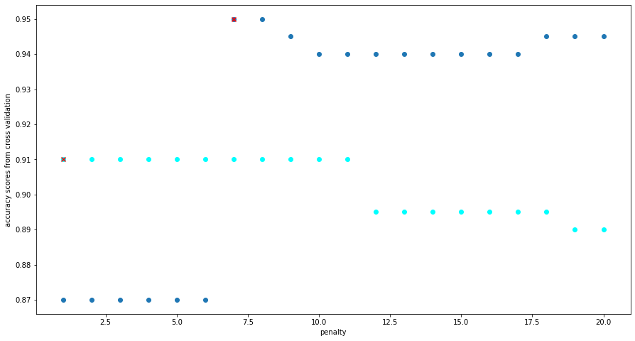

```python
plt.figure(figsize=(15, 8))
plt.scatter(penalty_range, test_scores_bal)
plt.scatter(best_test_score_bal[0], best_test_score_bal[1], color='red', marker='x')
plt.xlabel('penalty')
plt.ylabel('accuracy scores from cross validation')

plt.scatter(penalty_range, test_scores, color='cyan')
plt.scatter(best_test_score[0], best_test_score[1], color='red', marker='x')
plt.show()
```

```
The optimal penalty is 3200 with an area under the curve of 0.9986.
```

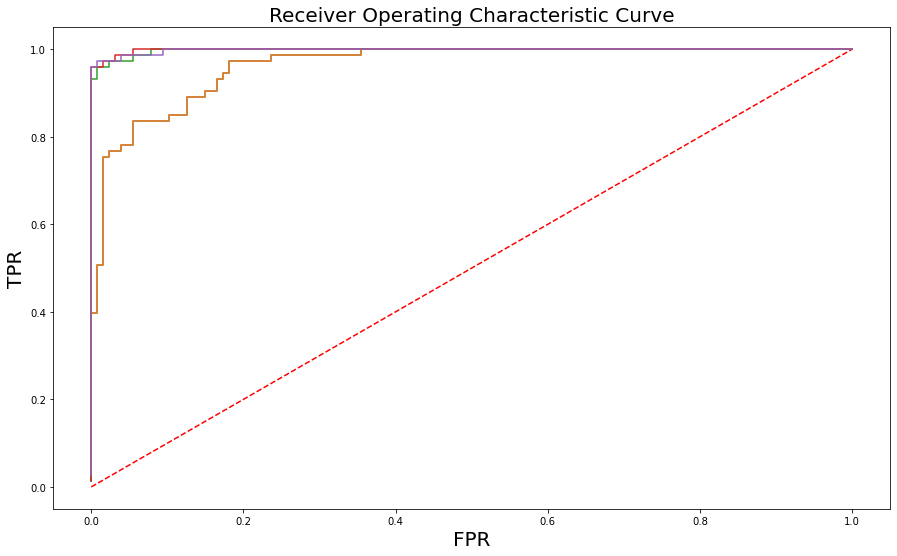

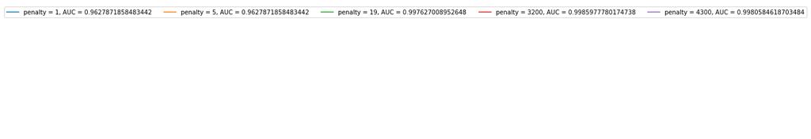

```
(3200, 0.9985977780174738)
```

```python
roc_plots(np.array([1, 5, 19, 3200, 4300]), bal_standardised_X_without_diagnosis_SVM, bal_diagnosis_SVM, standardised_X_test_without_diagnosis_SVM, diagnosis_SVM_test)
```

This concludes the notebook. Thank you for your time in reading this project and we hope you found it insightful.